# Coculture analysis

### Species level

```r
mamomaco_sps <- tax_glom(mamomaco, taxrank = "Species")

maize_sps <- as.data.frame (mamomaco_sps@otu_table)

maize_sps_sup15 <- maize_sps[rowSums(maize_sps) > 15,]

maize_sps_sup15_max6 <- maize_sps_sup15[rowSums(maize_sps_sup15 ==0) <= 6,]

tax_maize_sps_sup15_max6 <- subset(tax, rownames(tax) %in% rownames(maize_sps_sup15_max6))

mmvsmc_sps_s15m6 <- DESeqDataSetFromMatrix(maize_sps_sup15_max6,
                                 meta_data_mamomaco,
                                 design = ~ culture)
mmvsmc_sps_s15m6 <- DESeq(mmvsmc_sps_s15m6)

mmvsmc_sps_s15m6_res <- results(mmvsmc_sps_s15m6, cooksCutoff = FALSE)

alpha = 0.05

sps_maize_s15m6_sigtab = mmvsmc_sps_s15m6_res[which(mmvsmc_sps_s15m6_res$padj <= alpha), ]

sps_maize_s15m6_sigtab
```

```
## log2 fold change (MLE): culture maize.bean vs maize
## Wald test p-value: culture maize.bean vs maize
## DataFrame with 2 rows and 6 columns
##          baseMean log2FoldChange     lfcSE      stat       pvalue
##         <numeric>      <numeric> <numeric> <numeric>    <numeric>
## OTU198   62.78208       6.288901  1.594029  3.945285 7.970501e-05
## OTU826 1256.08462      -4.518425  1.004443 -4.498439 6.845408e-06
##               padj
##          <numeric>
## OTU198 0.036584601
## OTU826 0.006284085
```

```r
#Up

sps_maize_s15m6_sigtab_up <- sps_maize_s15m6_sigtab[which(sps_maize_s15m6_sigtab@listData$log2FoldChange > 0),]

cbind(head(sps_maize_s15m6_sigtab_up[order(sps_maize_s15m6_sigtab_up$padj),]), tax[row.names(head(sps_maize_s15m6_sigtab_up[order(sps_maize_s15m6_sigtab_up$padj),])),2:7])
```

```
## DataFrame with 1 row and 12 columns
##         baseMean log2FoldChange     lfcSE      stat       pvalue      padj
##        <numeric>      <numeric> <numeric> <numeric>    <numeric> <numeric>
## OTU198  62.78208       6.288901  1.594029  3.945285 7.970501e-05 0.0365846
##                Phylum               Class         Order         Family
##              <factor>            <factor>      <factor>       <factor>
## OTU198 proteobacteria alphaproteobacteria rickettsiales rickettsiaceae
##           Genus                Species
##        <factor>               <factor>
## OTU198 orientia orientia tsutsugamushi
```

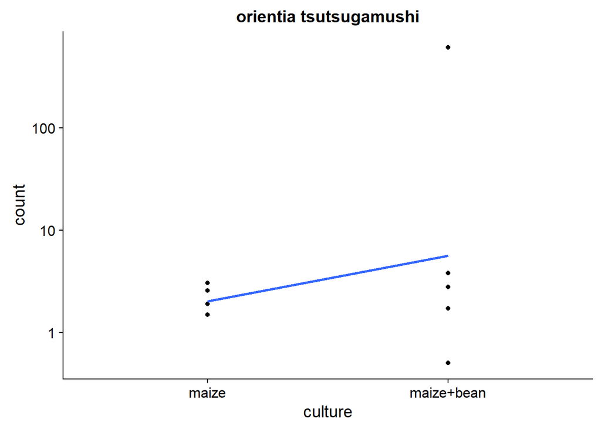

```r
plots.list <- lapply(row.names(head(sps_maize_s15m6_sigtab_up[order(sps_maize_s15m6_sigtab_up$padj),])),
                     function(x) {
                       d <- plotCounts(mmvsmc_sps_s15m6, x, intgroup=c("culture"), returnData=TRUE)
                       ggplot(d, aes(x=culture, y=count, group=1)) +
                         geom_point() + stat_smooth(se=FALSE,method="loess") + scale_y_log10() +
                         ggtitle(tax[x,"Species"]) +
                         theme(legend.title=element_blank(), legend.position="top", legend.box="horizontal", legend.key.height = unit(.5, "cm"),legend.text=element_text(size=6))
                     }
)
do.call(grid.arrange,plots.list)
```

Interestingly, this specie is an obligate intracellular bacterium, known for causing Scrub Typhus, it can be found in soil among his vector microbiome, trombiculid mites (Alison Luce-Fedrow et al., 2017, Rawadee Kumlert et al 2018). Hopefully, this is an annotation error, resulting in attributing the wrong genus to those sequences. If it’s not, it could be a bad new for the polyculture farmers near Tarbes, but I never heard about important rickettsiosis outbreak in France.

```r
#Down

sps_maize_s15m6_sigtab_down <- sps_maize_s15m6_sigtab[which(sps_maize_s15m6_sigtab@listData$log2FoldChange < 0),]

cbind(head(sps_maize_s15m6_sigtab_down[order(sps_maize_s15m6_sigtab_down$padj),]), tax[row.names(head(sps_maize_s15m6_sigtab_down[order(sps_maize_s15m6_sigtab_down$padj),])),2:7])
```

```
## DataFrame with 1 row and 12 columns
##         baseMean log2FoldChange     lfcSE      stat       pvalue
##        <numeric>      <numeric> <numeric> <numeric>    <numeric>
## OTU826  1256.085      -4.518425  1.004443 -4.498439 6.845408e-06
##               padj        Phylum            Class              Order
##          <numeric>      <factor>         <factor>           <factor>
## OTU826 0.006284085 bacteroidetes sphingobacteriia sphingobacteriales
##                     Family      Genus                 Species
##                   <factor>   <factor>                <factor>
## OTU826 sphingobacteriaceae pedobacter pedobacter daejeonensis
```

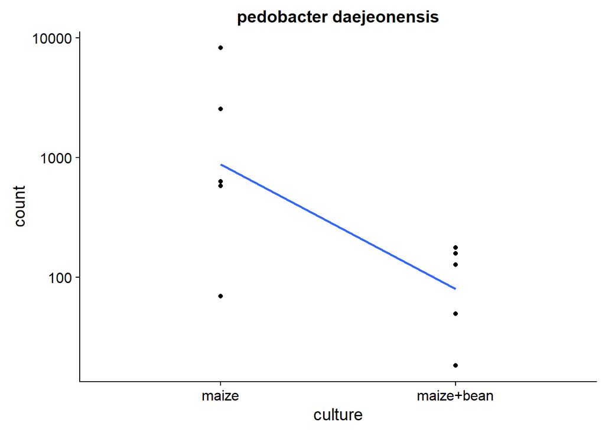

```r
plots.list <- lapply(row.names(head(sps_maize_s15m6_sigtab_down[order(sps_maize_s15m6_sigtab_down$padj),])),
                     function(x) {
                       d <- plotCounts(mmvsmc_sps_s15m6, x, intgroup=c("culture"), returnData=TRUE)
                       ggplot(d, aes(x=culture, y=count, group=1)) +
                         geom_point() + stat_smooth(se=FALSE,method="loess") + scale_y_log10() +
                         ggtitle(tax[x,"Species"]) +
                         theme(legend.title=element_blank(), legend.position="top", legend.box="horizontal", legend.key.height = unit(.5, "cm"),legend.text=element_text(size=6))
                     }
)
do.call(grid.arrange,plots.list)
```

```r
ma_sp <- tax_glom(physeq, taxrank = "Species")
ma_sp <- subset_samples(ma_sp, condition != "bean")
ma_sp <- subset_samples(ma_sp, compartment != "bean-rhizo")
ma_sp_concom <- merge_samples(ma_sp, "concom")
ma_sp_concom@sam_data$concom = c("maize _ bulk", "maize _ maize-rhizo", "maize+bean _ bulk", "maize+bean _ maize-rhizo")

ma_sp_concom_ped <- subset_taxa(ma_sp_concom,Species =="pedobacter daejeonensis")
```

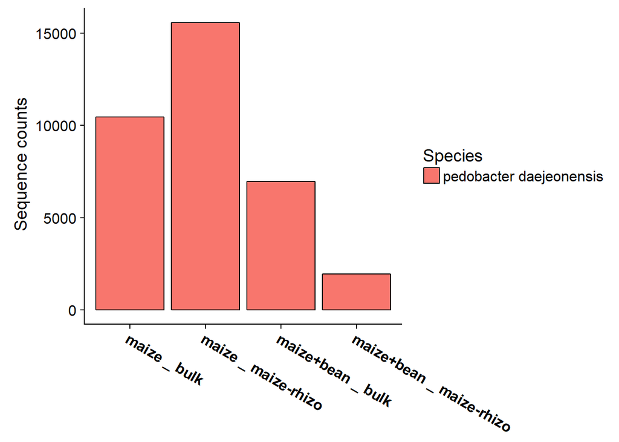

```r
ma_sp_concom_ped %>%
  plot_bar(fill = "Species",
         x = "concom")+
  theme(axis.text.x = element_text(angle = 330, size = 12, face = "bold"),
        axis.title.x = element_blank())+
  ylab(label = " Sequence counts")
```

```r
be_sp <- tax_glom(physeq, taxrank = "Species")
be_sp <- subset_samples(be_sp, condition != "maize")
be_sp <- subset_samples(be_sp, compartment != "maize-rhizo")
be_sp_concom <- merge_samples(be_sp, "concom")
be_sp_concom@sam_data$concom = c("bean _ bean-rhizo", "bean _ bulk", "maize+bean _ bean-rhizo", "maize+bean _ bulk")

be_sp_concom_ped <- subset_taxa(be_sp_concom,Species =="pedobacter daejeonensis")
```

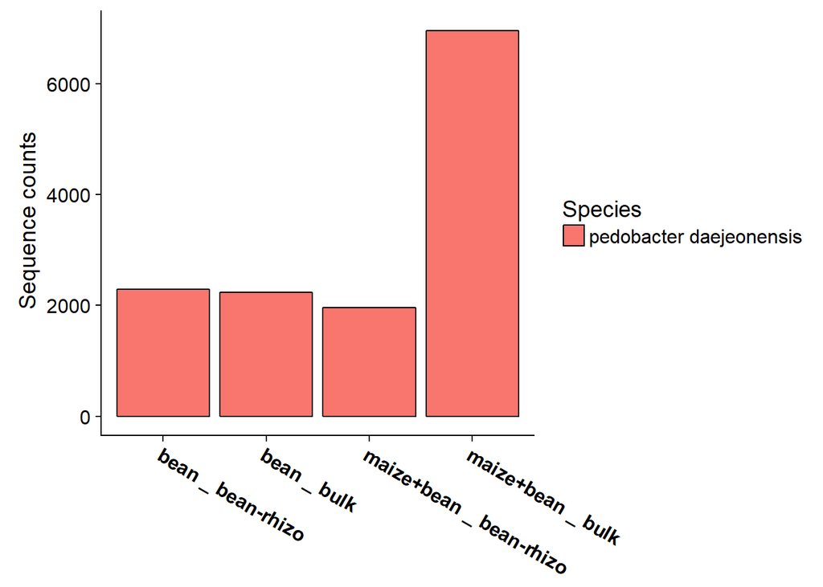

```r
be_sp_concom_ped %>%
  plot_bar(fill = "Species",
         x = "concom")+
  theme(axis.text.x = element_text(angle = 330, size = 12, face = "bold"),
        axis.title.x = element_blank())+
  ylab(label = " Sequence counts")
```

According to the analysis, the Specie “*pedobacter daejeonensis*” abundance decrease under polyculture treatment. The maize monoculture condition displays a higher amount of sequences in the rhizosphere compartment than in the bulk soil. But it’s clearly the opposite for the polyculture condition. When looking at the bean monoculture condition, the *pedobacter daejeonensis* abundance is almost the same in the rhizosphere compartment and the bulk soil. For the polyculture treatment, this specie abundance is clearly lower within the rhizosphere compartment than within the bulk soil. Given those results, since the *pedobacter daejeonensis* abundance is almost equal within the bulk soil and rhizosphere compartment for the bean monoculture condition, this specie seems not to be counter selected by the bean rhizosphere, but just not particularly attracted. Hence, the decreased abundance of this specie within the maize rhizosphere compartment under polyculture treatment could be the result of a maize-rhizodeposits dilution by the bean rhizodeposits, ineffective in stimulating this OTU.

##### High variance

```r
mamomaco_sps_highVar0.5 =
  filter_taxa(mamomaco_sps,
              function(x) var(x) > 0.5, TRUE)

maize_sps_highVar0.5 <- as.data.frame (mamomaco_sps_highVar0.5@otu_table)

maize_sps_highVar0.5_sup15 <- maize_sps_highVar0.5[rowSums(maize_sps_highVar0.5) > 15,]

maize_sps_highVar0.5_sup15_max6 <- maize_sps_highVar0.5_sup15[rowSums(maize_sps_highVar0.5_sup15 ==0) <= 6,]

tax_maize_sps_highVar0.5_sup15_max6 <- subset(tax, rownames(tax) %in% rownames(maize_sps_highVar0.5_sup15_max6))

mmvsmc_hv_sps_s15m6 <- DESeqDataSetFromMatrix(maize_sps_highVar0.5_sup15_max6,
                                 meta_data_mamomaco,
                                 design = ~ culture)
mmvsmc_hv_sps_s15m6 <- DESeq(mmvsmc_hv_sps_s15m6)

mmvsmc_hv_sps_s15m6_res <- results(mmvsmc_hv_sps_s15m6, cooksCutoff = FALSE)

alpha = 0.05

sps_maize_hv_s15m6_sigtab = mmvsmc_hv_sps_s15m6_res[which(mmvsmc_hv_sps_s15m6_res$padj <= alpha), ]

sps_maize_hv_s15m6_sigtab
```

```
## log2 fold change (MLE): culture maize.bean vs maize
## Wald test p-value: culture maize.bean vs maize
## DataFrame with 2 rows and 6 columns
##          baseMean log2FoldChange     lfcSE      stat       pvalue
##         <numeric>      <numeric> <numeric> <numeric>    <numeric>
## OTU198   62.78208       6.288901  1.594029  3.945285 7.970501e-05
## OTU826 1256.08462      -4.518425  1.004443 -4.498439 6.845408e-06
##               padj
##          <numeric>
## OTU198 0.036584601
## OTU826 0.006284085
```

```r
#Up

sps_maize_hv_s15m6_sigtab_up <- sps_maize_hv_s15m6_sigtab[which(sps_maize_hv_s15m6_sigtab@listData$log2FoldChange > 0),]

cbind(head(sps_maize_hv_s15m6_sigtab_up[order(sps_maize_hv_s15m6_sigtab_up$padj),]), tax[row.names(head(sps_maize_hv_s15m6_sigtab_up[order(sps_maize_hv_s15m6_sigtab_up$padj),])),2:7])
```

```
## DataFrame with 1 row and 12 columns
##         baseMean log2FoldChange     lfcSE      stat       pvalue      padj
##        <numeric>      <numeric> <numeric> <numeric>    <numeric> <numeric>
## OTU198  62.78208       6.288901  1.594029  3.945285 7.970501e-05 0.0365846
##                Phylum               Class         Order         Family
##              <factor>            <factor>      <factor>       <factor>
## OTU198 proteobacteria alphaproteobacteria rickettsiales rickettsiaceae
##           Genus                Species
##        <factor>               <factor>
## OTU198 orientia orientia tsutsugamushi
```

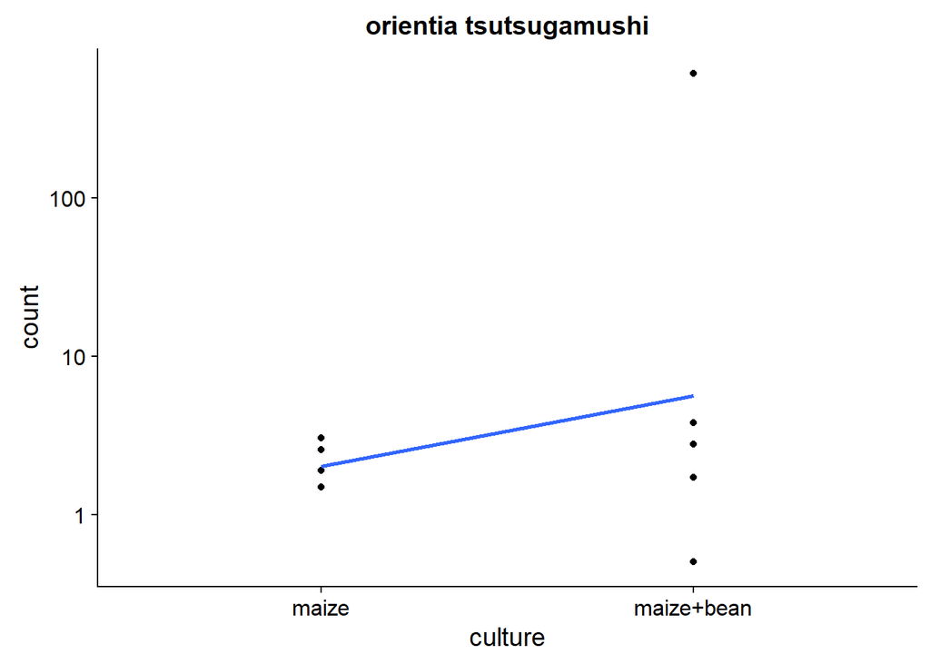

```r
plots.list <- lapply(row.names(head(sps_maize_hv_s15m6_sigtab_up[order(sps_maize_hv_s15m6_sigtab_up$padj),])),
                     function(x) {
                       d <- plotCounts(mmvsmc_hv_sps_s15m6, x, intgroup=c("culture"), returnData=TRUE)
                       ggplot(d, aes(x=culture, y=count, group=1)) +
                         geom_point() + stat_smooth(se=FALSE,method="loess") + scale_y_log10() +
                         ggtitle(tax[x,"Species"]) +
                         theme(legend.title=element_blank(), legend.position="top", legend.box="horizontal", legend.key.height = unit(.5, "cm"),legend.text=element_text(size=6))
                     }
)
do.call(grid.arrange,plots.list)
```

```r
#Down

sps_maize_hv_s15m6_sigtab_down <- sps_maize_hv_s15m6_sigtab[which(sps_maize_hv_s15m6_sigtab@listData$log2FoldChange < 0),]

cbind(head(sps_maize_hv_s15m6_sigtab_down[order(sps_maize_hv_s15m6_sigtab_down$padj),]), tax[row.names(head(sps_maize_hv_s15m6_sigtab_down[order(sps_maize_hv_s15m6_sigtab_down$padj),])),2:7])
```

```
## DataFrame with 1 row and 12 columns
##         baseMean log2FoldChange     lfcSE      stat       pvalue
##        <numeric>      <numeric> <numeric> <numeric>    <numeric>
## OTU826  1256.085      -4.518425  1.004443 -4.498439 6.845408e-06
##               padj        Phylum            Class              Order
##          <numeric>      <factor>         <factor>           <factor>
## OTU826 0.006284085 bacteroidetes sphingobacteriia sphingobacteriales
##                     Family      Genus                 Species
##                   <factor>   <factor>                <factor>
## OTU826 sphingobacteriaceae pedobacter pedobacter daejeonensis
```

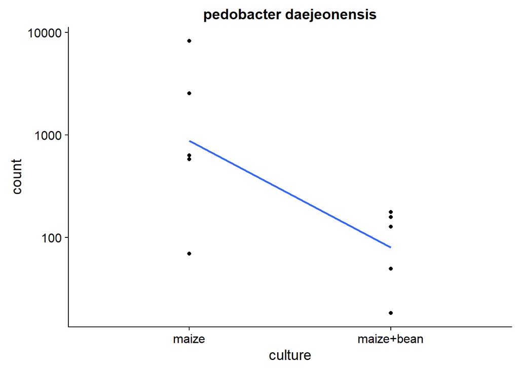

```r
plots.list <- lapply(row.names(head(sps_maize_hv_s15m6_sigtab_down[order(sps_maize_hv_s15m6_sigtab_down$padj),])),
                     function(x) {
                       d <- plotCounts(mmvsmc_hv_sps_s15m6, x, intgroup=c("culture"), returnData=TRUE)
                       ggplot(d, aes(x=culture, y=count, group=1)) +
                         geom_point() + stat_smooth(se=FALSE,method="loess") + scale_y_log10() +
                         ggtitle(tax[x,"Species"]) +
                         theme(legend.title=element_blank(), legend.position="top", legend.box="horizontal", legend.key.height = unit(.5, "cm"),legend.text=element_text(size=6))
                     }
)
do.call(grid.arrange,plots.list)
```

Same pettern than without filtering.

### OTU level

```r
maize_otus <- as.data.frame (mamomaco@otu_table)

maize_otus_sup15 <- maize_otus[rowSums(maize_otus) > 15,]

maize_otus_sup15_max6 <- maize_otus_sup15[
  rowSums(maize_otus_sup15 == 0)
  <= 6,]

tax_mmvsmc_otus_sup15_m6 <- subset(tax, rownames(tax) %in% rownames(maize_otus_sup15_max6))

mmvsmc_otus_s15m6 <- DESeqDataSetFromMatrix(maize_otus_sup15_max6,
                                 meta_data_mamomaco,
                                 design = ~ culture)
mmvsmc_otus_s15m6 <- DESeq(mmvsmc_otus_s15m6)

mmvsmc_otus_s15m6_res <- results(mmvsmc_otus_s15m6, cooksCutoff = FALSE)

alpha = 0.05

otus_maize_s15m6_sigtab = mmvsmc_otus_s15m6_res[which(mmvsmc_otus_s15m6_res$padj <= alpha), ]

otus_maize_s15m6_sigtab
```

```
## log2 fold change (MLE): culture maize.bean vs maize
## Wald test p-value: culture maize.bean vs maize
## DataFrame with 12 rows and 6 columns
##            baseMean log2FoldChange     lfcSE      stat       pvalue
##           <numeric>      <numeric> <numeric> <numeric>    <numeric>
## OTU93     126.86130      -6.795885  1.549225 -4.386634 1.151182e-05
## OTU102    145.05219      -6.366726  1.251723 -5.086371 3.649791e-07
## OTU12091  385.01403      -4.601219  1.318643 -3.489360 4.841787e-04
## OTU4769    69.39468      -5.971250  1.629977 -3.663396 2.488936e-04
## OTU485     23.12605       6.258699  1.376044  4.548328 5.407393e-06
## ...             ...            ...       ...       ...          ...
## OTU198     62.98867       6.400843  1.768066  3.620252 2.943167e-04
## OTU826   1133.62687      -4.441206  1.006910 -4.410728 1.030236e-05
## OTU2062    17.13440      -5.843235  1.386445 -4.214546 2.502817e-05
## OTU188     33.74354      -4.303907  1.096712 -3.924373 8.695583e-05
## OTU6878   248.79532       3.990053  1.046358  3.813276 1.371370e-04
##                  padj
##             <numeric>
## OTU93    0.0034046204
## OTU102   0.0004317703
## OTU12091 0.0477319543
## OTU4769  0.0368051483
## OTU485   0.0031984727
## ...               ...
## OTU198    0.038686301
## OTU826    0.003404620
## OTU2062   0.005921664
## OTU188    0.017144791
## OTU6878   0.023176152
```

```r
#UP
otus_maize_s15m6_sigtab_up <- otus_maize_s15m6_sigtab[which(otus_maize_s15m6_sigtab@listData$log2FoldChange > 0),]

cbind(head(otus_maize_s15m6_sigtab_up[order(otus_maize_s15m6_sigtab_up$padj),]), tax[row.names(head(otus_maize_s15m6_sigtab_up[order(otus_maize_s15m6_sigtab_up$padj),])),2:7])
```

```
## DataFrame with 3 rows and 12 columns
##          baseMean log2FoldChange     lfcSE      stat       pvalue
##         <numeric>      <numeric> <numeric> <numeric>    <numeric>
## OTU485   23.12605       6.258699  1.376044  4.548328 5.407393e-06
## OTU6878 248.79532       3.990053  1.046358  3.813276 1.371370e-04
## OTU198   62.98867       6.400843  1.768066  3.620252 2.943167e-04
##                padj         Phylum               Class              Order
##           <numeric>       <factor>            <factor>           <factor>
## OTU485  0.003198473 proteobacteria gammaproteobacteria    methylococcales
## OTU6878 0.023176152  bacteroidetes    sphingobacteriia sphingobacteriales
## OTU198  0.038686301 proteobacteria alphaproteobacteria      rickettsiales
##                      Family            Genus                Species
##                    <factor>         <factor>               <factor>
## OTU485     methylococcaceae methylomicrobium methylomicrobium agile
## OTU6878 sphingobacteriaceae       pedobacter         pedobacter sp.
## OTU198       rickettsiaceae         orientia orientia tsutsugamushi
```

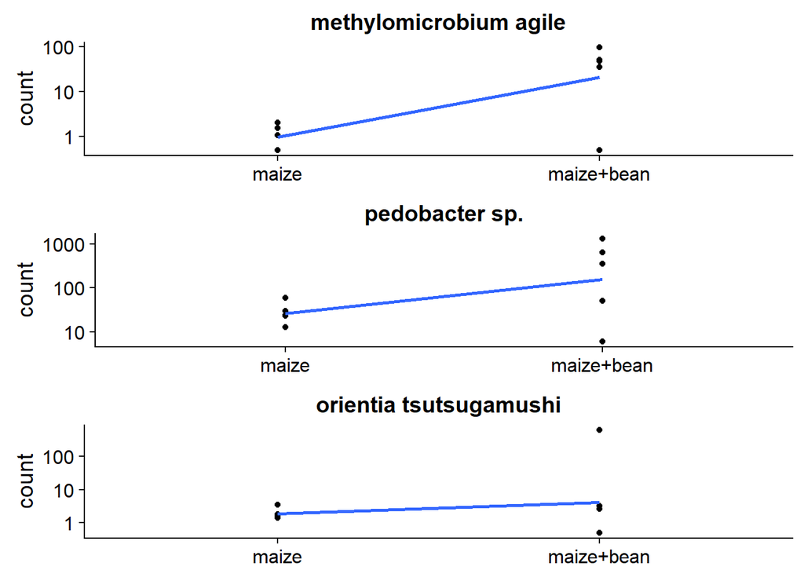

```r
plots.list <- lapply(row.names(head(otus_maize_s15m6_sigtab_up[order(otus_maize_s15m6_sigtab_up$padj),])),
                     function(x) {
                       d <- plotCounts(mmvsmc_otus_s15m6, x, intgroup=c("culture"), returnData=TRUE)
                       ggplot(d, aes(x=culture, y=count, group=1)) +
                         geom_point() + stat_smooth(se=FALSE,method="loess") + scale_y_log10() +
                         ggtitle(tax[x,"Species"]) +
                         theme(axis.title.x = element_blank(), legend.title=element_blank(), legend.position="top", legend.box="horizontal", legend.key.height = unit(.5, "cm"),legend.text=element_text(size=6))
                     }
)
do.call(grid.arrange,plots.list)
```

```r
ma_otu <- subset_samples(physeq, condition != "bean")
ma_otu <- subset_samples(ma_otu, compartment != "bean-rhizo")
ma_otu_concom <- merge_samples(ma_otu, "concom")
ma_otu_concom@sam_data$concom = c("maize _ bulk", "maize _ maize-rhizo", "maize+bean _ bulk", "maize+bean _ maize-rhizo")

ma_otu_concom_met <- prune_taxa("OTU485", ma_otu_concom)
```

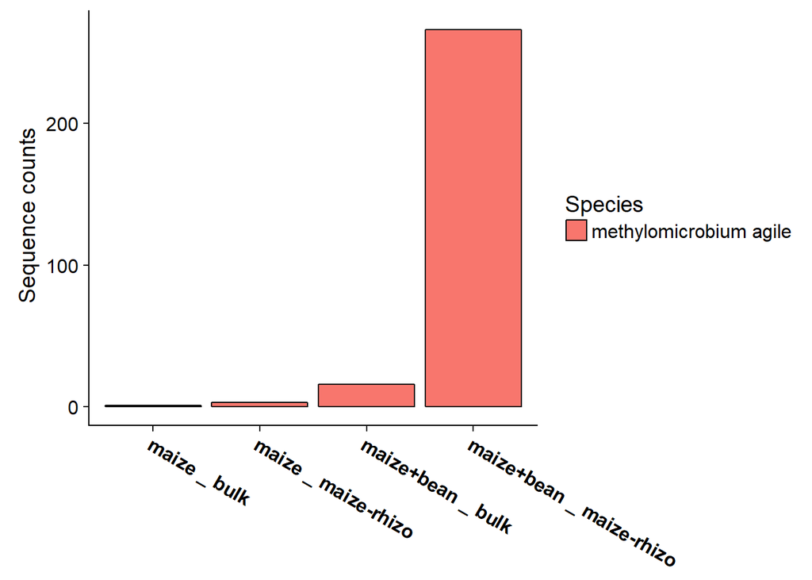

```r
ma_otu_concom_met %>%
  plot_bar(fill = "Species",
         x = "concom")+
  theme(axis.text.x = element_text(angle = 330, size = 12, face = "bold"),
        axis.title.x = element_blank())+
  ylab(label = " Sequence counts")
```

```r
be_otu <- subset_samples(physeq, condition != "maize")
be_otu <- subset_samples(be_otu, compartment != "maize-rhizo")
be_otu_concom <- merge_samples(be_otu, "concom")
be_otu_concom@sam_data$concom = c("bean _ bean-rhizo", "bean _ bulk", "maize+bean _ bean-rhizo", "maize+bean _ bulk")

be_otu_concom_met <- prune_taxa("OTU485", be_otu_concom)
```

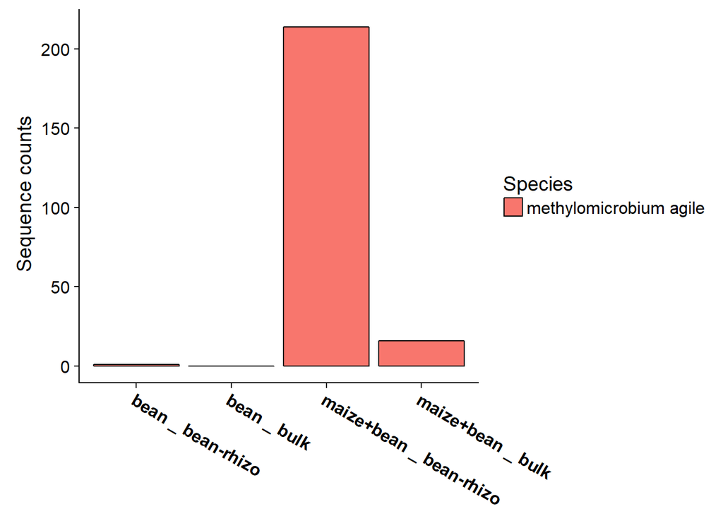

```r
be_otu_concom_met %>%
  plot_bar(fill = "Species",
         x = "concom")+
  theme(axis.text.x = element_text(angle = 330, size = 12, face = "bold"),
        axis.title.x = element_blank())+
  ylab(label = " Sequence counts")
```

Here, the interpretation is still uncertain. Two reasons could explain why both bean and maize rhizosphere under polyculture treatment display a higher abundance of this OTU than under monoculture treatment. Firstly, because the bulk soil for both maize and bean monoculture is not attractive for this OTU, then even if those plant rhizospheres are attractive for this OTU, the surrounding environment (which is soil) is not welcoming. Secondly, the physicochemical soil proprieties could not be responsible for this abundance difference, but rhizodeposit mix could. That would mean that this OTU needs a more complex nutrient mix than it can find within a monoculture rhizosphere compartment. To choose between those two hypotheses, an isolation work for this particular OTU is needed. Then a mock community greenhouse experiment (with homogeneous soil physicochemical proprieties) could be conducted to verify whether this OTU can thrive as well within a monoculture rhizosphere than within polyculture rhizospheres.

```r
ma_otu_concom_ortsu <- prune_taxa("OTU198", ma_otu_concom)
```

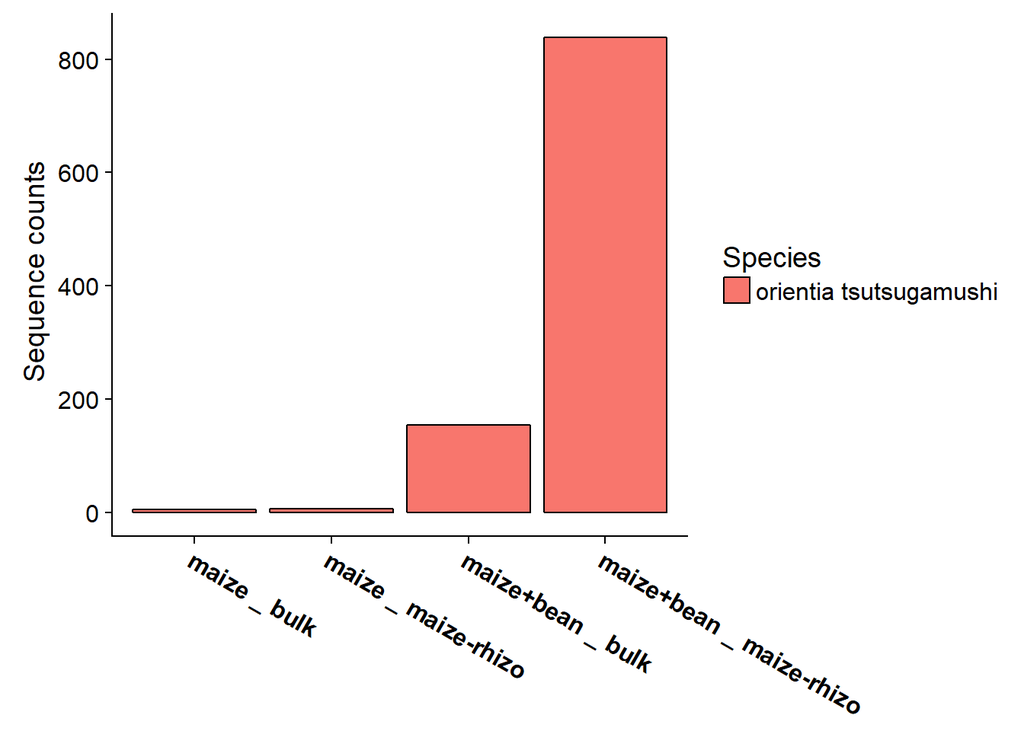

```r
ma_otu_concom_ortsu %>%
  plot_bar(fill = "Species",
         x = "concom")+
  theme(axis.text.x = element_text(angle = 330, size = 12, face = "bold"),
        axis.title.x = element_blank())+
  ylab(label = " Sequence counts")
```

```r
be_otu_concom_ortsu <- prune_taxa("OTU198", be_otu_concom)
```

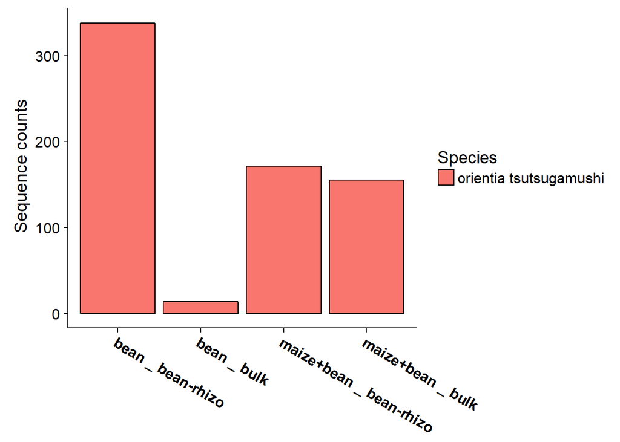

```r
be_otu_concom_ortsu %>%
  plot_bar(fill = "Species",
         x = "concom")+
  theme(axis.text.x = element_text(angle = 330, size = 12, face = "bold"),
        axis.title.x = element_blank())+
  ylab(label = " Sequence counts")
```

The same pattern is observed for the OTU198 than for its higher taxonomical rank (*Orientia tsutsugamushi*).

```r
ma_otu_concom_pedsp <- prune_taxa("OTU6878", ma_otu_concom)
```

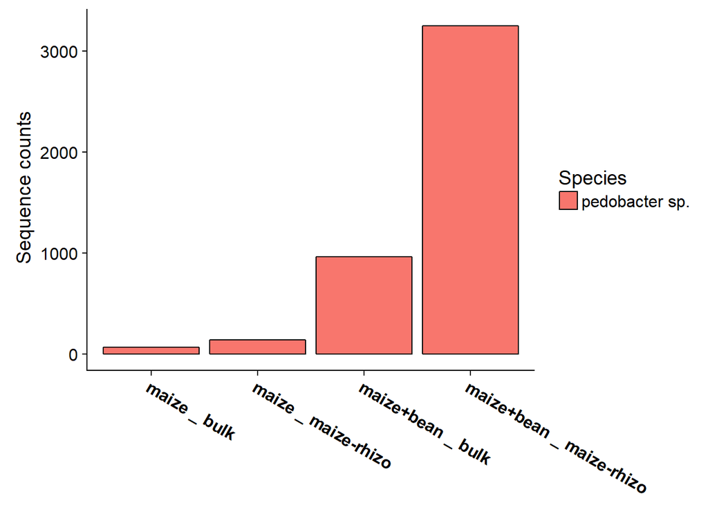

```r
ma_otu_concom_pedsp %>%
  plot_bar(fill = "Species",
         x = "concom")+
  theme(axis.text.x = element_text(angle = 330, size = 12, face = "bold"),
        axis.title.x = element_blank())+
  ylab(label = " Sequence counts")
```

```r
be_otu_concom_pedsp <- prune_taxa("OTU6878", be_otu_concom)
```

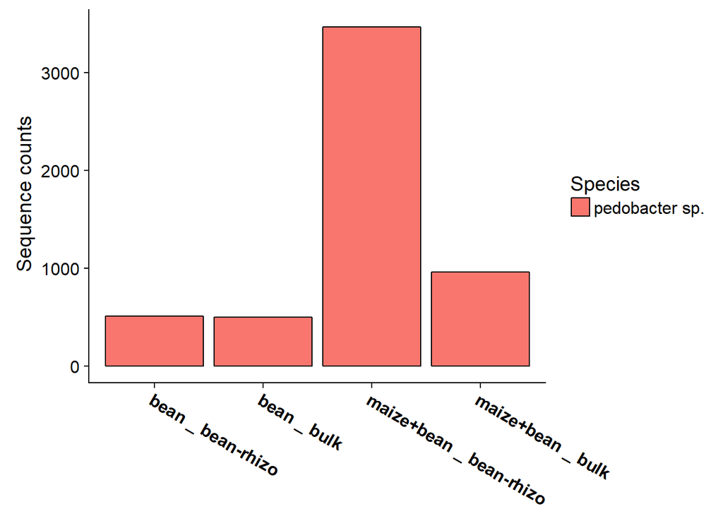

```r
be_otu_concom_pedsp %>%
  plot_bar(fill = "Species",
         x = "concom")+
  theme(axis.text.x = element_text(angle = 330, size = 12, face = "bold"),
        axis.title.x = element_blank())+
  ylab(label = " Sequence counts")
```

About the OTU6878, (a member of one of the *Pedobacter* species) a quite similar pattern is observed that for the OTU485 (*Methylobacterium agile*). except that the monoculture bulk soil displays more sequences. Also here the difference between mono and polyculture bulk soil - rhizosphere ratio is higher for the bean. That means that maize rhizosphere seems to contain more sequences of that OTU for both mono and polyculture treatment. But in the case of the bean, monoculture bulk soil and bean rhizosphere exhibit almost the same amount of sequences, whereas polyculture bean rhizosphere shows a net increase of OTU6878 sequences compared to bulk soil. Altogether, those result could suggest that the bean rhizosphere could have been enriched in OTU6878 because of the maize rhizosphere proximity.

```r
#DOwn
otus_maize_s15m6_sigtab_down <- otus_maize_s15m6_sigtab[which(otus_maize_s15m6_sigtab@listData$log2FoldChange < 0),]

cbind(otus_maize_s15m6_sigtab_down[order(otus_maize_s15m6_sigtab_down$padj),], tax[row.names(otus_maize_s15m6_sigtab_down[order(otus_maize_s15m6_sigtab_down$padj),]),2:7])
```

```
## DataFrame with 9 rows and 12 columns
##            baseMean log2FoldChange     lfcSE      stat       pvalue
##           <numeric>      <numeric> <numeric> <numeric>    <numeric>
## OTU102    145.05219      -6.366726 1.2517226 -5.086371 3.649791e-07
## OTU93     126.86130      -6.795885 1.5492254 -4.386634 1.151182e-05
## OTU826   1133.62687      -4.441206 1.0069099 -4.410728 1.030236e-05
## OTU2062    17.13440      -5.843235 1.3864448 -4.214546 2.502817e-05
## OTU188     33.74354      -4.303907 1.0967118 -3.924373 8.695583e-05
## OTU4769    69.39468      -5.971250 1.6299767 -3.663396 2.488936e-04
## OTU1734    77.32083      -3.385134 0.9453524 -3.580817 3.425211e-04
## OTU817     23.49478      -6.900515 1.9507785 -3.537314 4.042195e-04
## OTU12091  385.01403      -4.601219 1.3186428 -3.489360 4.841787e-04
##                  padj         Phylum               Class
##             <numeric>       <factor>            <factor>
## OTU102   0.0004317703  bacteroidetes    sphingobacteriia
## OTU93    0.0034046204  bacteroidetes    sphingobacteriia
## OTU826   0.0034046204  bacteroidetes    sphingobacteriia
## OTU2062  0.0059216644  bacteroidetes    sphingobacteriia
## OTU188   0.0171447911 proteobacteria alphaproteobacteria
## OTU4769  0.0368051483  bacteroidetes    sphingobacteriia
## OTU1734  0.0405202452  bacteroidetes    sphingobacteriia
## OTU817   0.0434719689 actinobacteria      actinobacteria
## OTU12091 0.0477319543  bacteroidetes    sphingobacteriia
##                       Order              Family           Genus
##                    <factor>            <factor>        <factor>
## OTU102   sphingobacteriales    chitinophagaceae    chitinophaga
## OTU93    sphingobacteriales sphingobacteriaceae      pedobacter
## OTU826   sphingobacteriales sphingobacteriaceae      pedobacter
## OTU2062  sphingobacteriales sphingobacteriaceae      pedobacter
## OTU188     sphingomonadales   sphingomonadaceae     sphingobium
## OTU4769  sphingobacteriales    chitinophagaceae flavisolibacter
## OTU1734  sphingobacteriales sphingobacteriaceae      pedobacter
## OTU817      actinomycetales     actinospicaceae     actinospica
## OTU12091 sphingobacteriales    chitinophagaceae ferruginibacter
##                           Species
##                          <factor>
## OTU102          chitinophaga spp.
## OTU93             pedobacter spp.
## OTU826    pedobacter daejeonensis
## OTU2062   pedobacter daejeonensis
## OTU188   sphingobium paucimobilis
## OTU4769      flavisolibacter spp.
## OTU1734     pedobacter kribbensis
## OTU817            actinospica sp.
## OTU12091      ferruginibacter sp.
```

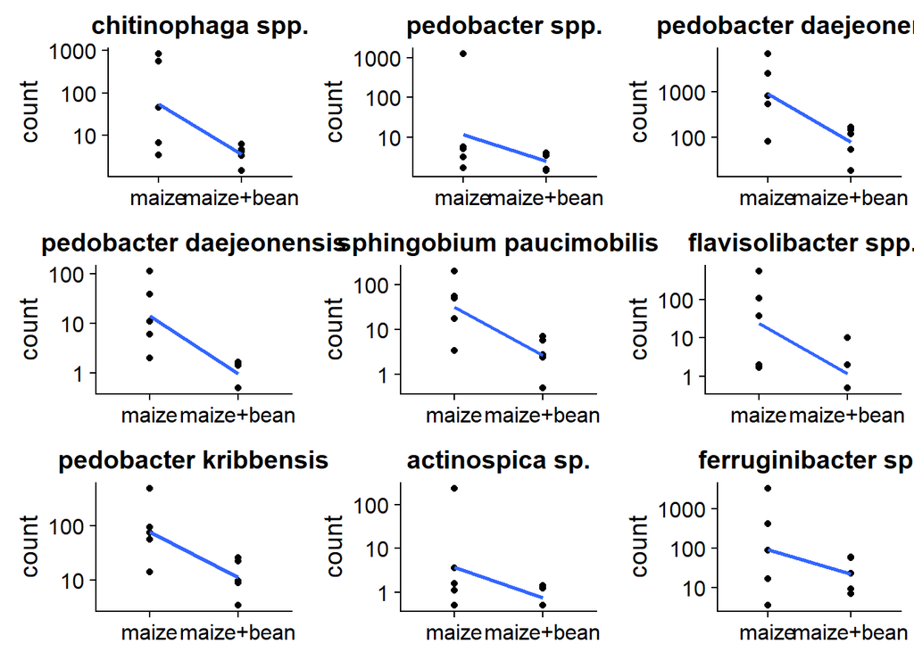

```r
plots.list <- lapply(row.names(otus_maize_s15m6_sigtab_down[order(otus_maize_s15m6_sigtab_down$padj),]),
                     function(x) {
                       d <- plotCounts(mmvsmc_otus_s15m6, x, intgroup=c("culture"), returnData=TRUE)
                       ggplot(d, aes(x=culture, y=count, group=1)) +
                         geom_point() + stat_smooth(se=FALSE,method="loess") + scale_y_log10() +
                         ggtitle(tax[x,"Species"]) +
                         theme(axis.title.x = element_blank(), legend.title=element_blank(), legend.position="top", legend.box="horizontal", legend.key.height = unit(.5, "cm"),legend.text=element_text(size=6))
                     }
)
do.call(grid.arrange,plots.list)
```

```r
ma_otu_concom_chispp <- prune_taxa("OTU102", ma_otu_concom)
```

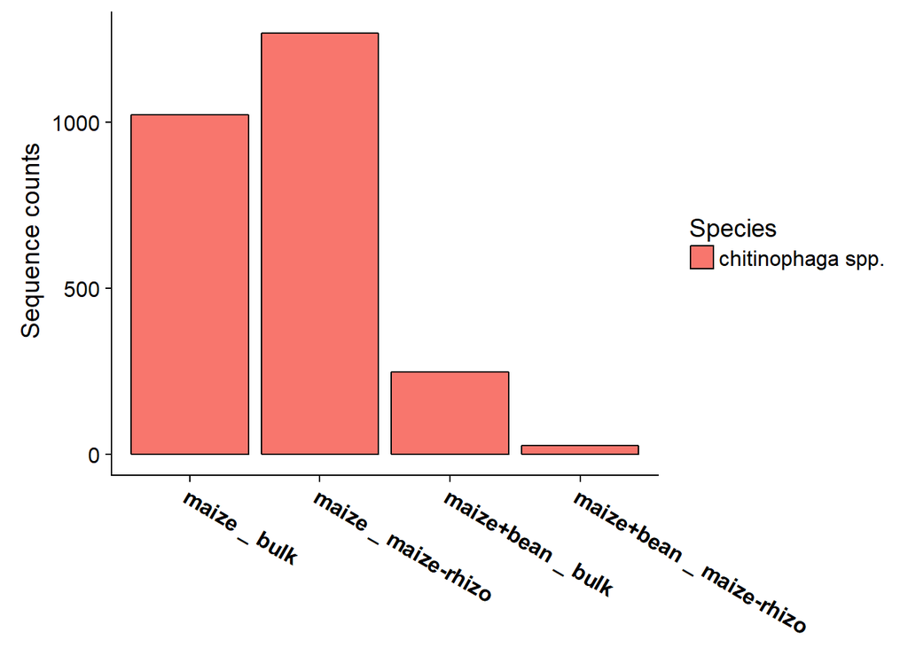

```r
ma_otu_concom_chispp %>%
  plot_bar(fill = "Species",
         x = "concom")+
  theme(axis.text.x = element_text(angle = 330, size = 12, face = "bold"),
        axis.title.x = element_blank())+
  ylab(label = " Sequence counts")
```

```r
be_otu_concom_chispp <- prune_taxa("OTU102", be_otu_concom)
```

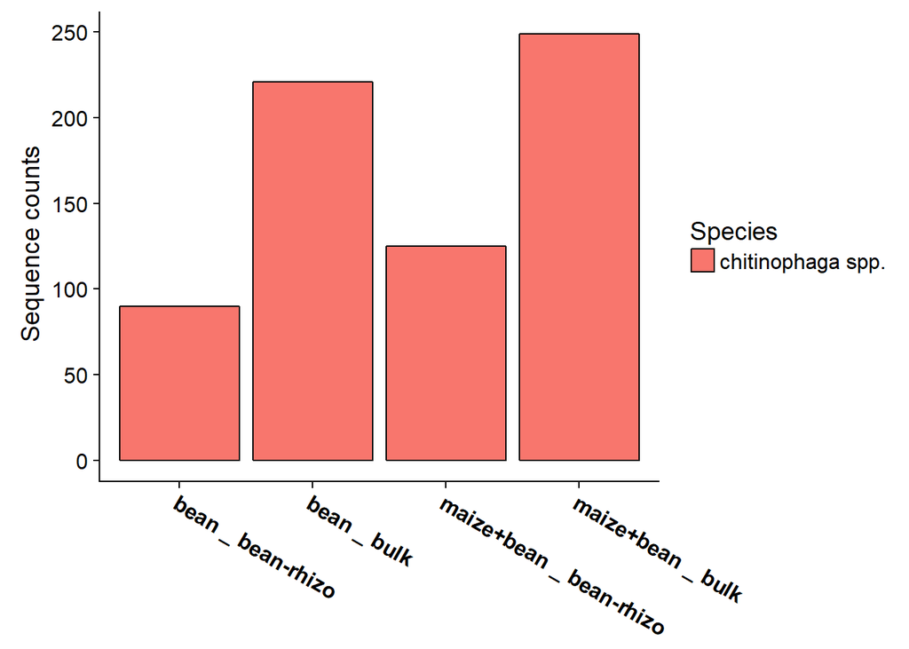

```r
be_otu_concom_chispp %>%
  plot_bar(fill = "Species",
         x = "concom")+
  theme(axis.text.x = element_text(angle = 330, size = 12, face = "bold"),
        axis.title.x = element_blank())+
  ylab(label = " Sequence counts")
```

The case of the OTU102 is interesting because it’s the opposite of what we observed just above. Indeed, more sequences from this OTU were detected within the monoculture maize rhizosphere that within the corresponding bulk soil. But under polyculture condition, the number of sequences from this OTU is clearly lower within the maize rhizosphere compartment that within the corresponding bulk soil. When looking to the bean rhizosphere, for both mono and polyculture treatments, bean rhizosphere displayed a smaller number of sequences from this OTU that the corresponding bulk soil. Suggesting that beans could somehow counter select the OTU102 within the rhizosphere compartment and that this ability persisted under polyculture condition.

```r
ma_otu_concom_pespp <- prune_taxa("OTU93", ma_otu_concom)
```

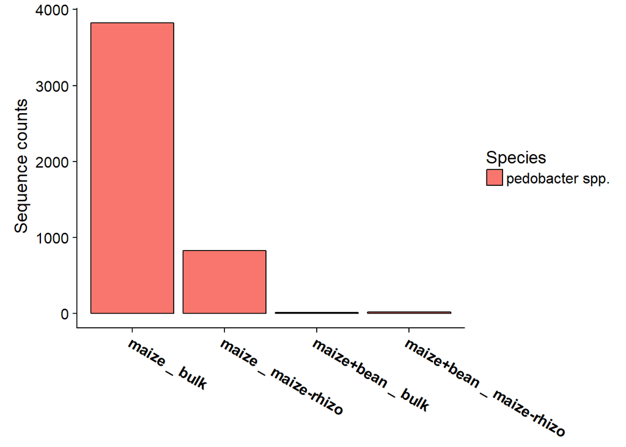

```r
ma_otu_concom_pespp %>%
  plot_bar(fill = "Species",
         x = "concom")+
  theme(axis.text.x = element_text(angle = 330, size = 12, face = "bold"),
        axis.title.x = element_blank())+
  ylab(label = " Sequence counts")
```

```r
be_otu_concom_pespp <- prune_taxa("OTU93", be_otu_concom)
```

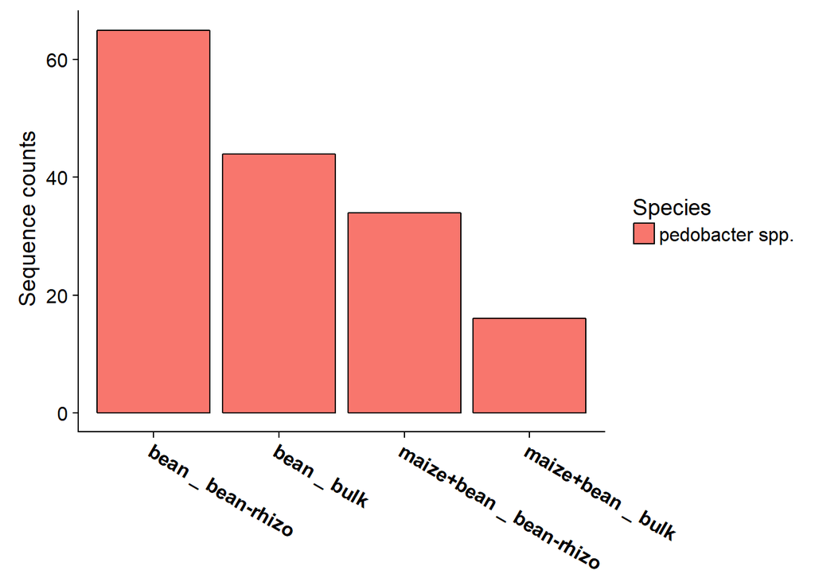

```r
be_otu_concom_pespp %>%
  plot_bar(fill = "Species",
         x = "concom")+
  theme(axis.text.x = element_text(angle = 330, size = 12, face = "bold"),
        axis.title.x = element_blank())+
  ylab(label = " Sequence counts")
```

It’s not really possible to compare the OTU93 abundance within the maize rhizosphere between mono and polyculture, because this OTU under polyculture condition was almost not present neither in the bulk soil neither within the maize rhizosphere compartment, hence the difference between mono and polyculture is more likely to be a “soil effect” rather than a “polyculture effect.

```r
ma_otu_concom_pedae1 <- prune_taxa("OTU826", ma_otu_concom)
```

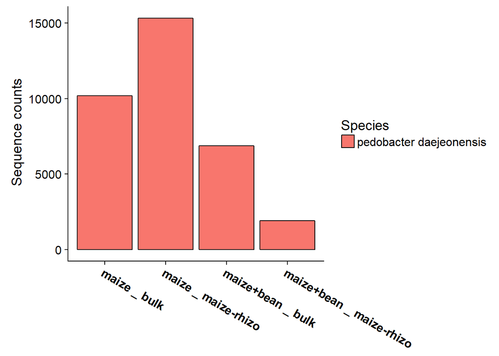

```r
ma_otu_concom_pedae1 %>%
  plot_bar(fill = "Species",
         x = "concom")+
  theme(axis.text.x = element_text(angle = 330, size = 12, face = "bold"),
        axis.title.x = element_blank())+
  ylab(label = " Sequence counts")
```

```r
be_otu_concom_pedae1 <- prune_taxa("OTU826", be_otu_concom)
```

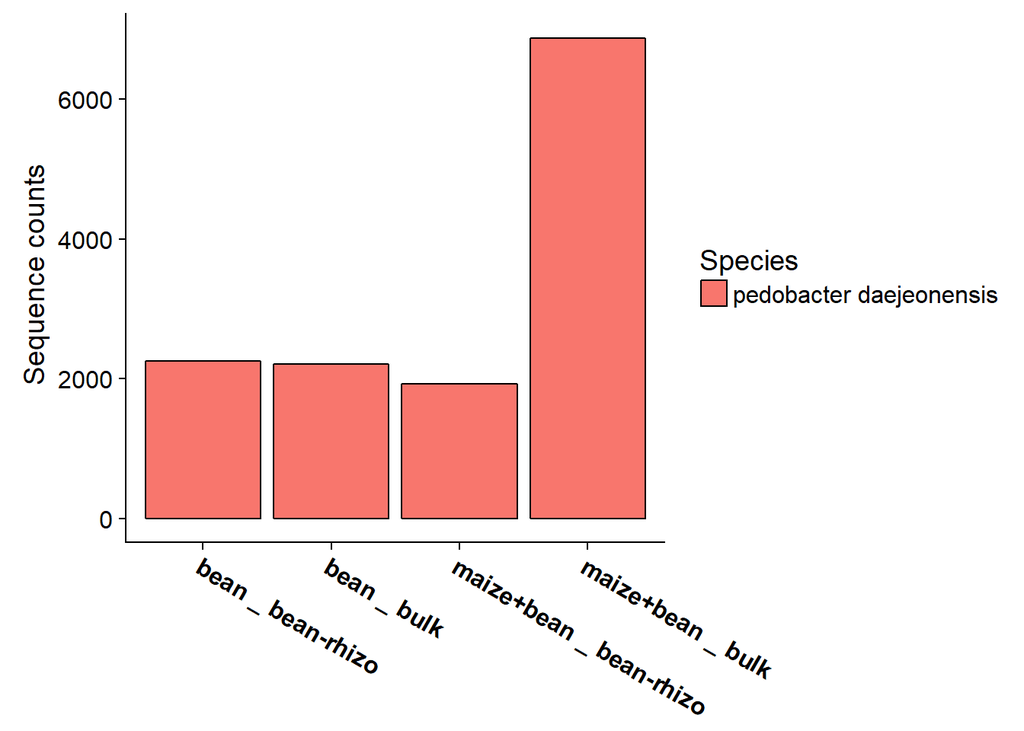

```r
be_otu_concom_pedae1 %>%
  plot_bar(fill = "Species",
         x = "concom")+
  theme(axis.text.x = element_text(angle = 330, size = 12, face = "bold"),
        axis.title.x = element_blank())+
  ylab(label = " Sequence counts")
```

Moving on the OTU826 (*Pedobacter daejeonensis*), a new pattern can be observed. Indeed, its abundance seems to be higher within the monoculture maize rhizosphere that within the corresponding bulk soil. But it’s the opposite under polyculture condition. When looking at what happened for beans, the OTU829 number of sequences is quite similar between the monoculture rhizosphere and the corresponding bulk soil. But under polyculture condition, bulk soil shows a clearly higher number of sequences that the bean rhizosphere compartment. Hence, the maize-bean association could somehow repress the maize ability to attract this OTU with the rhizosphere.

```r
ma_otu_concom_pedae2 <- prune_taxa("OTU2062", ma_otu_concom)
```

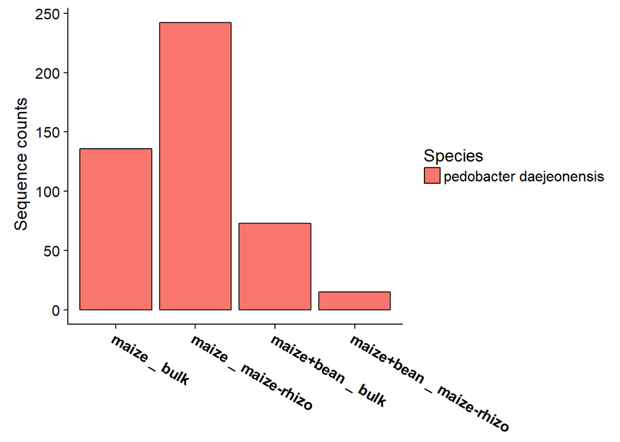

```r
ma_otu_concom_pedae2 %>%
  plot_bar(fill = "Species",
         x = "concom")+
  theme(axis.text.x = element_text(angle = 330, size = 12, face = "bold"),
        axis.title.x = element_blank())+
  ylab(label = " Sequence counts")
```

```r
be_otu_concom_pedae2 <- prune_taxa("OTU2062", be_otu_concom)
```

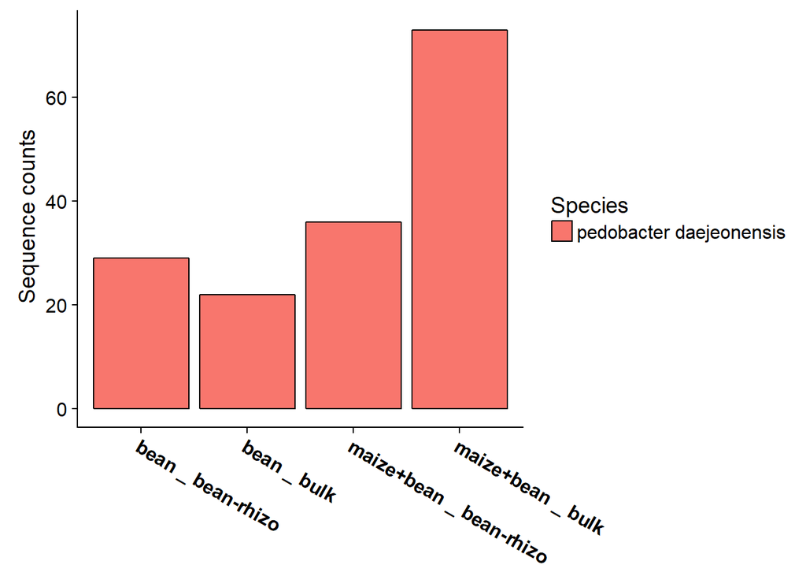

```r
be_otu_concom_pedae2 %>%
  plot_bar(fill = "Species",
         x = "concom")+
  theme(axis.text.x = element_text(angle = 330, size = 12, face = "bold"),
        axis.title.x = element_blank())+
  ylab(label = " Sequence counts")
```

For the OTU2062, belonging to the *Pedobacter daejeonensis* specie, a quite similar pattern that for the OTU826 (also a member of the *Pedobacter daejeonensis* specie) can be observed. Maybe because those strains are very phylogenetically close together they share a very similar ecological niche and respond the same way to those treatments.

```r
ma_otu_concom_sppa <- prune_taxa("OTU188", ma_otu_concom)
```

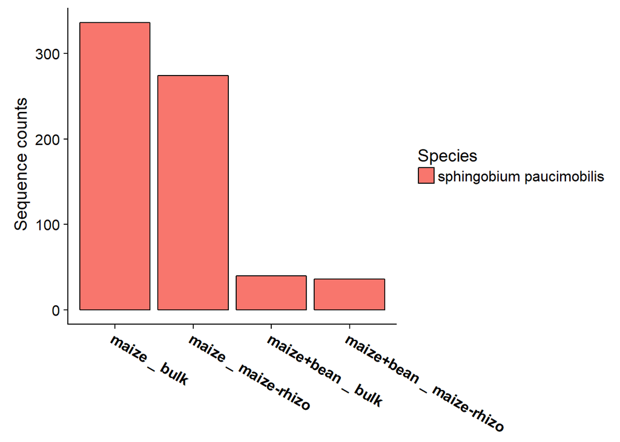

```r
ma_otu_concom_sppa %>%
  plot_bar(fill = "Species",
         x = "concom")+
  theme(axis.text.x = element_text(angle = 330, size = 12, face = "bold"),
        axis.title.x = element_blank())+
  ylab(label = " Sequence counts")
```

```r
be_otu_concom_sppa <- prune_taxa("OTU188", be_otu_concom)
```

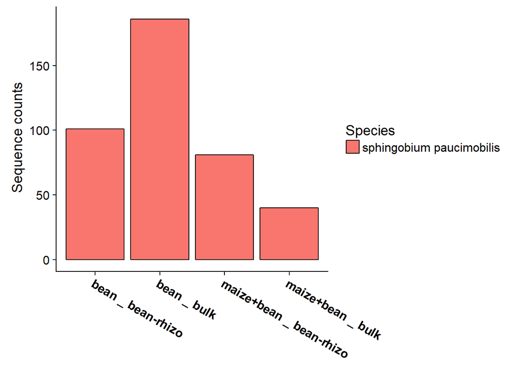

```r
be_otu_concom_sppa %>%
  plot_bar(fill = "Species",
         x = "concom")+
  theme(axis.text.x = element_text(angle = 330, size = 12, face = "bold"),
        axis.title.x = element_blank())+
  ylab(label = " Sequence counts")
```

Comparison between mono and polyculture is not easy for the OTU188, the number of sequences is very different between mono and polyculture for both maize and bean. The difference observed here between mono and polyculture maize rhizosphere-compartment OTU188 sequence-number could be more likely due to soil proprieties.

```r
ma_otu_concom_flsp <- prune_taxa("OTU4769", ma_otu_concom)
```

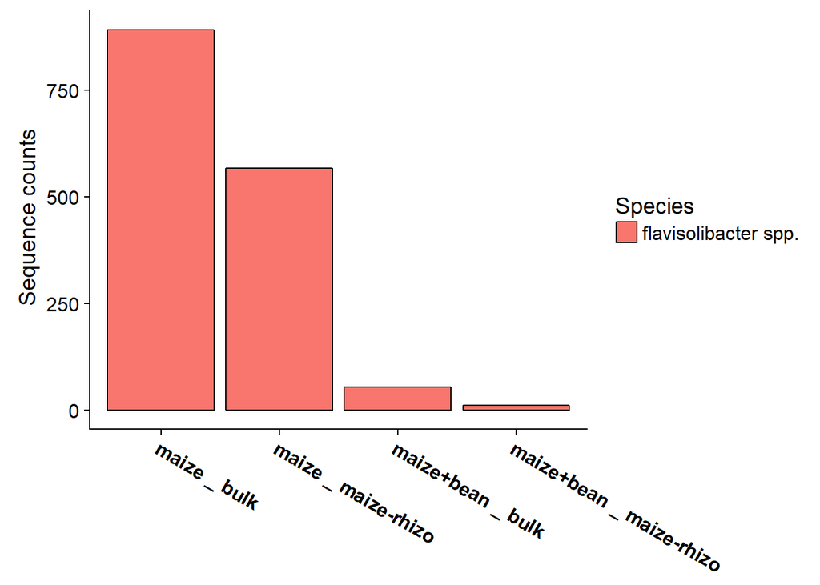

```r
ma_otu_concom_flsp %>%
  plot_bar(fill = "Species",
         x = "concom")+
  theme(axis.text.x = element_text(angle = 330, size = 12, face = "bold"),
        axis.title.x = element_blank())+
  ylab(label = " Sequence counts")
```

```r
be_otu_concom_flsp <- prune_taxa("OTU4769", be_otu_concom)
```

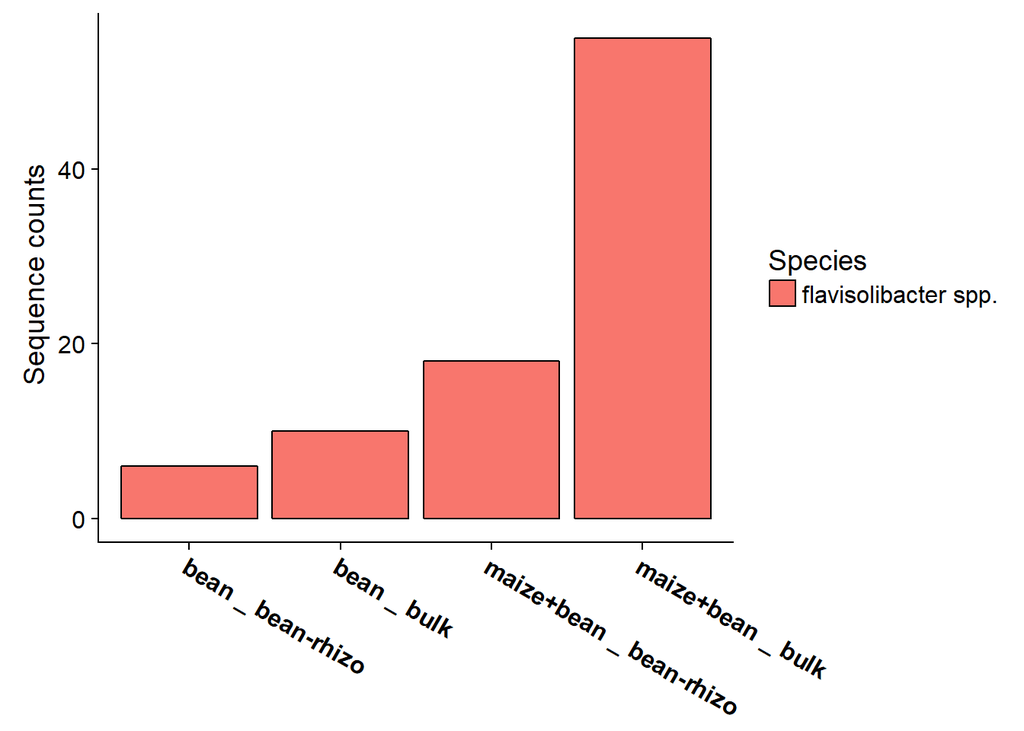

```r
be_otu_concom_flsp %>%
  plot_bar(fill = "Species",
         x = "concom")+
  theme(axis.text.x = element_text(angle = 330, size = 12, face = "bold"),
        axis.title.x = element_blank())+
  ylab(label = " Sequence counts")
```

For both mono and polyculture, also both maize and bean, the number of sequences from the OTU4769 (*Flavisolibacter spp.*) is higher within the bulk soil that within the corresponding rhizosphere compartment. So, here again, the differences observed is probably due to soil proprieties.

```r
ma_otu_concom_pekr <- prune_taxa("OTU1734", ma_otu_concom)
```

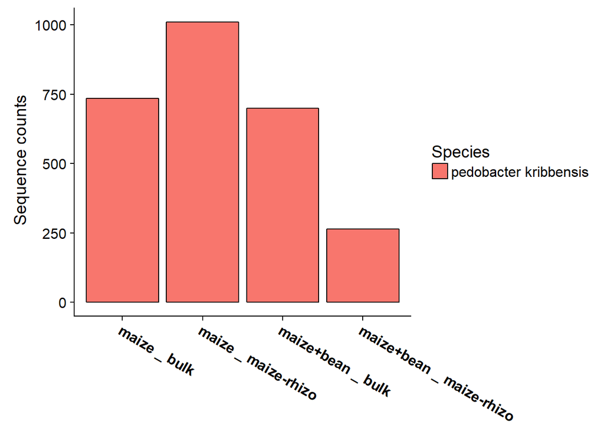

```r
ma_otu_concom_pekr %>%
  plot_bar(fill = "Species",
         x = "concom")+
  theme(axis.text.x = element_text(angle = 330, size = 12, face = "bold"),
        axis.title.x = element_blank())+
  ylab(label = " Sequence counts")
```

```r
be_otu_concom_pekr <- prune_taxa("OTU1734", be_otu_concom)
```

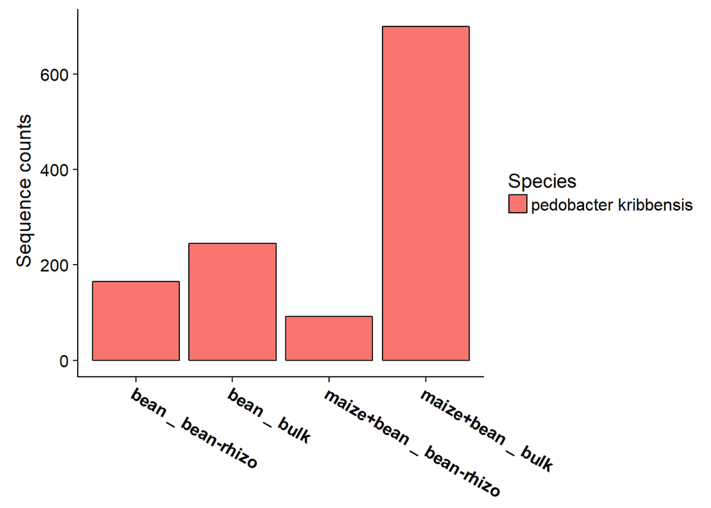

```r
be_otu_concom_pekr %>%
  plot_bar(fill = "Species",
         x = "concom")+
  theme(axis.text.x = element_text(angle = 330, size = 12, face = "bold"),
        axis.title.x = element_blank())+
  ylab(label = " Sequence counts")
```

So here, the development of this OTU could be inhibited by bean rhizodeposits, even under polyculture condition. This could be possible if the development of this OTU is enhanced within maize rhizosphere by nutrient supplied by maize rhizodeposit but repressed by a bean rhizodeposit (or even by a negative interaction with a bean rhizo-microbiome member, competing for the same nutrients for instance).

```r
ma_otu_concom_acsp <- prune_taxa("OTU817", ma_otu_concom)
```

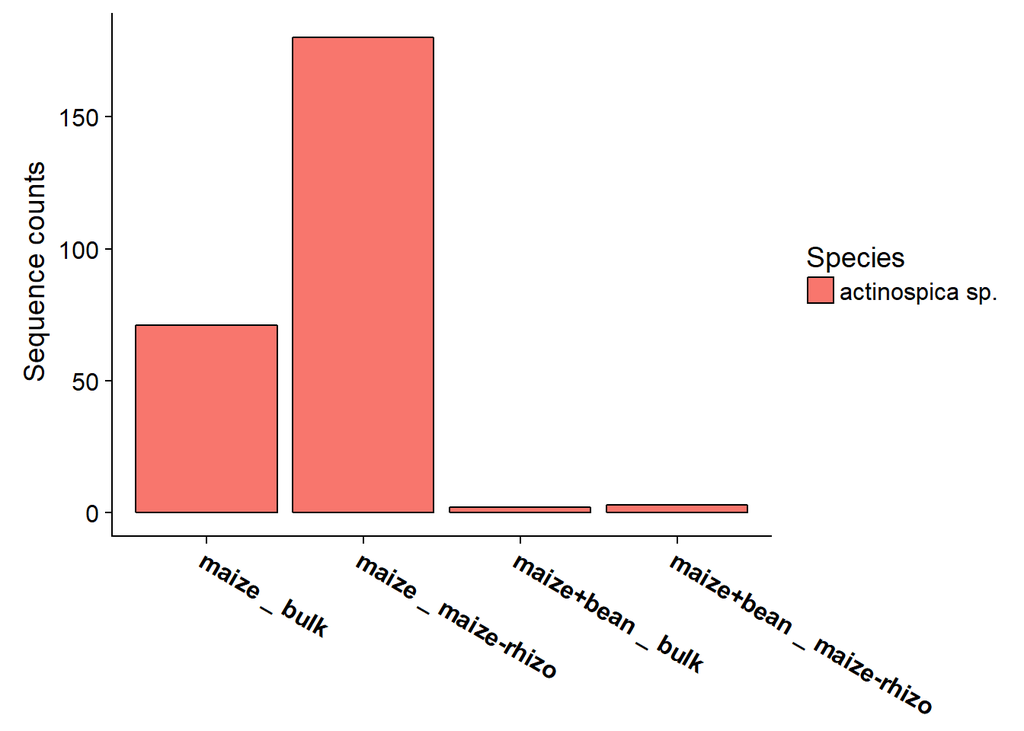

```r
ma_otu_concom_acsp %>%
  plot_bar(fill = "Species",
         x = "concom")+
  theme(axis.text.x = element_text(angle = 330, size = 12, face = "bold"),
        axis.title.x = element_blank())+
  ylab(label = " Sequence counts")
```

```r
be_otu_concom_acsp <- prune_taxa("OTU817", be_otu_concom)
```

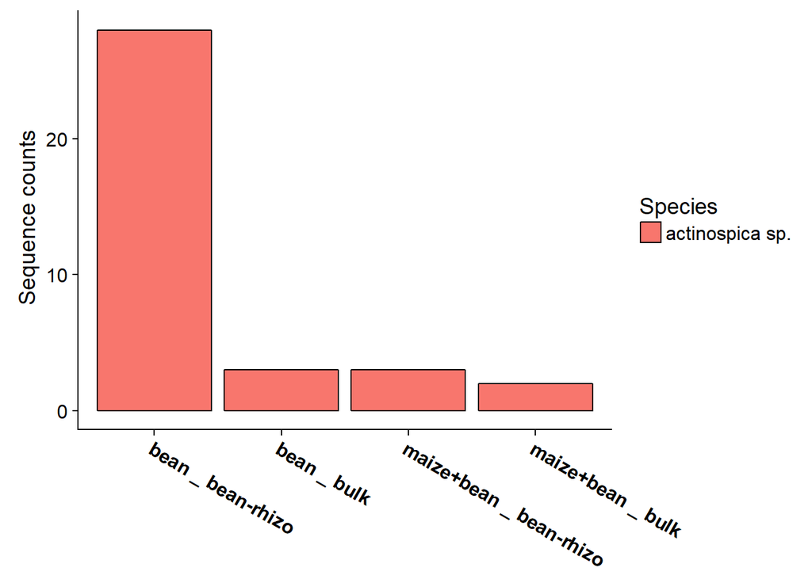

```r
be_otu_concom_acsp %>%
  plot_bar(fill = "Species",
         x = "concom")+
  theme(axis.text.x = element_text(angle = 330, size = 12, face = "bold"),
        axis.title.x = element_blank())+
  ylab(label = " Sequence counts")
```

What happened for the OTU817 (*Actinospica sp*) is probably due to soil proprieties. Indeed, for both maize and bean, under monoculture condition, the number of sequences from the OTU817 is higher within the Rhizosphere than within the corresponding bulk soil. It’s quite the same under polyculture condition but clearly of an order of magnitude lower. Hence, the development of this OTU within the rhizosphere seems to be more impacted by soil proprieties than culture conditions.

```r
ma_otu_concom_fesp <- prune_taxa("OTU12091", ma_otu_concom)
```

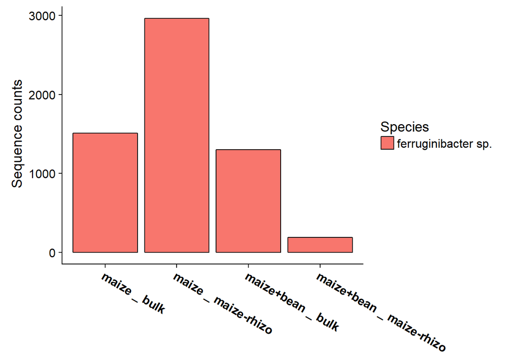

```r
ma_otu_concom_fesp %>%
  plot_bar(fill = "Species",
         x = "concom")+
  theme(axis.text.x = element_text(angle = 330, size = 12, face = "bold"),
        axis.title.x = element_blank())+
  ylab(label = " Sequence counts")
```

```r
be_otu_concom_fesp <- prune_taxa("OTU12091", be_otu_concom)
```

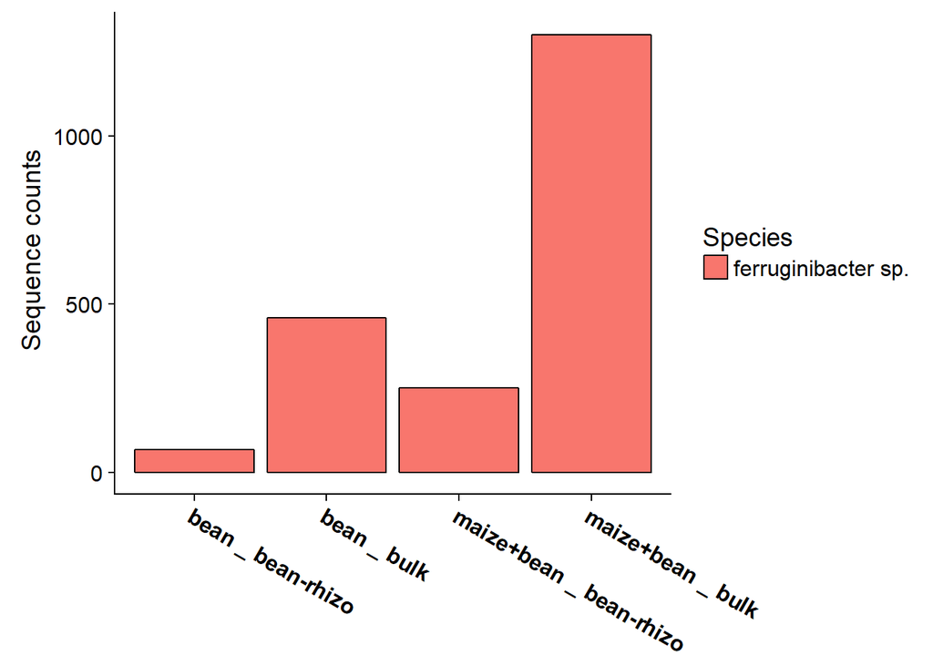

```r
be_otu_concom_fesp %>%
  plot_bar(fill = "Species",
         x = "concom")+
  theme(axis.text.x = element_text(angle = 330, size = 12, face = "bold"),
        axis.title.x = element_blank())+
  ylab(label = " Sequence counts")
```

For the OTU12091(*ferruginibacter sp.*), a pattern similar to what was observed for the OTU1734 (*Pedobacter kribbensis*). Suggesting that somehow, bean inhibit this OTU development within the rhizosphere over the maize ability to enhance it.

##### High variance

```r
mamomaco_otus_highVar0.5 =
  filter_taxa(mamomaco,
              function(x) var(x) > 0.5, TRUE)

maize_otus_highVar0.5 <- as.data.frame (mamomaco_otus_highVar0.5@otu_table)

maize_otus_highVar0.5_sup15 <- maize_otus_highVar0.5[rowSums(maize_otus_highVar0.5) > 15,]

maize_otus_highVar0.5_sup15_max6 <- maize_otus_highVar0.5_sup15[rowSums(maize_otus_highVar0.5_sup15 ==0) <= 6,]

tax_maize_otus_highVar0.5_sup15_max6 <- subset(tax, rownames(tax) %in% rownames(maize_otus_highVar0.5_sup15_max6))

mmvsmc_hv_otus_s15m6 <- DESeqDataSetFromMatrix(maize_otus_highVar0.5_sup15_max6,
                                 meta_data_mamomaco,
                                 design = ~ culture)
mmvsmc_hv_otus_s15m6 <- DESeq(mmvsmc_hv_otus_s15m6)

mmvsmc_hv_otus_s15m6_res <- results(mmvsmc_hv_otus_s15m6, cooksCutoff = FALSE)

alpha = 0.05

otus_maize_hv_s15m6_sigtab = mmvsmc_hv_otus_s15m6_res[which(mmvsmc_hv_otus_s15m6_res$padj <= alpha), ]

otus_maize_hv_s15m6_sigtab
```

```
## log2 fold change (MLE): culture maize.bean vs maize
## Wald test p-value: culture maize.bean vs maize
## DataFrame with 12 rows and 6 columns
##            baseMean log2FoldChange     lfcSE      stat       pvalue
##           <numeric>      <numeric> <numeric> <numeric>    <numeric>
## OTU93     126.86130      -6.795885  1.549225 -4.386634 1.151182e-05
## OTU102    145.05219      -6.366726  1.251723 -5.086371 3.649791e-07
## OTU12091  385.01403      -4.601219  1.318643 -3.489360 4.841787e-04
## OTU4769    69.39468      -5.971250  1.629977 -3.663396 2.488936e-04
## OTU485     23.12605       6.258699  1.376044  4.548328 5.407393e-06
## ...             ...            ...       ...       ...          ...
## OTU198     62.98867       6.400843  1.768066  3.620252 2.943167e-04
## OTU826   1133.62687      -4.441206  1.006910 -4.410728 1.030236e-05
## OTU2062    17.13440      -5.843235  1.386445 -4.214546 2.502817e-05
## OTU188     33.74354      -4.303907  1.096712 -3.924373 8.695583e-05
## OTU6878   248.79532       3.990053  1.046358  3.813276 1.371370e-04
##                  padj
##             <numeric>
## OTU93    0.0034046204
## OTU102   0.0004317703
## OTU12091 0.0477319543
## OTU4769  0.0368051483
## OTU485   0.0031984727
## ...               ...
## OTU198    0.038686301
## OTU826    0.003404620
## OTU2062   0.005921664
## OTU188    0.017144791
## OTU6878   0.023176152
```

```r
#UP
otus_maize_hv_s15m6_sigtab_up <- otus_maize_hv_s15m6_sigtab[which(otus_maize_hv_s15m6_sigtab@listData$log2FoldChange > 0),]

cbind(head(otus_maize_hv_s15m6_sigtab_up[order(otus_maize_hv_s15m6_sigtab_up$padj),]), tax[row.names(head(otus_maize_hv_s15m6_sigtab_up[order(otus_maize_hv_s15m6_sigtab_up$padj),])),2:7])
```

```
## DataFrame with 3 rows and 12 columns
##          baseMean log2FoldChange     lfcSE      stat       pvalue
##         <numeric>      <numeric> <numeric> <numeric>    <numeric>
## OTU485   23.12605       6.258699  1.376044  4.548328 5.407393e-06
## OTU6878 248.79532       3.990053  1.046358  3.813276 1.371370e-04
## OTU198   62.98867       6.400843  1.768066  3.620252 2.943167e-04
##                padj         Phylum               Class              Order
##           <numeric>       <factor>            <factor>           <factor>
## OTU485  0.003198473 proteobacteria gammaproteobacteria    methylococcales
## OTU6878 0.023176152  bacteroidetes    sphingobacteriia sphingobacteriales
## OTU198  0.038686301 proteobacteria alphaproteobacteria      rickettsiales
##                      Family            Genus                Species
##                    <factor>         <factor>               <factor>
## OTU485     methylococcaceae methylomicrobium methylomicrobium agile
## OTU6878 sphingobacteriaceae       pedobacter         pedobacter sp.
## OTU198       rickettsiaceae         orientia orientia tsutsugamushi
```

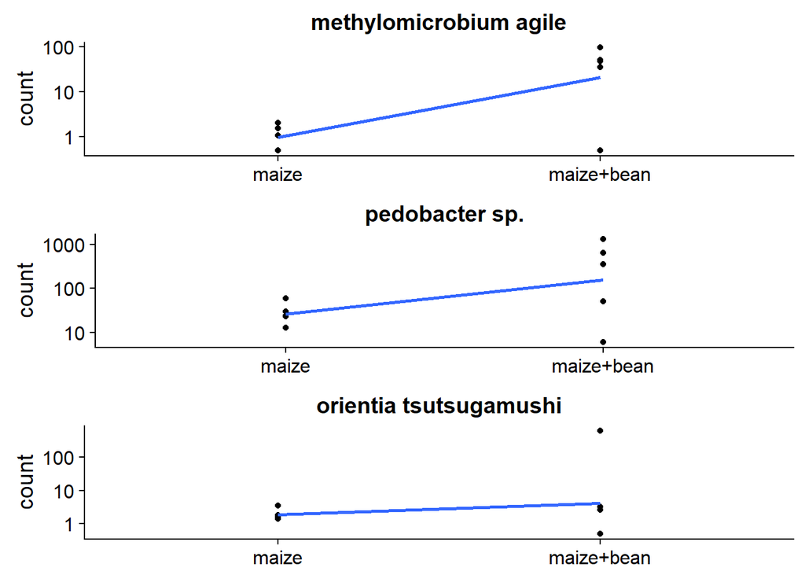

```r
plots.list <- lapply(row.names(head(otus_maize_hv_s15m6_sigtab_up[order(otus_maize_hv_s15m6_sigtab_up$padj),])),
                     function(x) {
                       d <- plotCounts(mmvsmc_hv_otus_s15m6, x, intgroup=c("culture"), returnData=TRUE)
                       ggplot(d, aes(x=culture, y=count, group=1)) +
                         geom_point() + stat_smooth(se=FALSE,method="loess") + scale_y_log10() +
                         ggtitle(tax[x,"Species"]) +
                         theme(axis.title.x = element_blank(), legend.title=element_blank(), legend.position="top", legend.box="horizontal", legend.key.height = unit(.5, "cm"),legend.text=element_text(size=6))
                     }
)
do.call(grid.arrange,plots.list)
```

```r
#DOwn
otus_maize_hv_s15m6_sigtab_down <- otus_maize_hv_s15m6_sigtab[which(otus_maize_hv_s15m6_sigtab@listData$log2FoldChange < 0),]

cbind(otus_maize_hv_s15m6_sigtab_down[order(otus_maize_hv_s15m6_sigtab_down$padj),], tax[row.names(otus_maize_hv_s15m6_sigtab_down[order(otus_maize_hv_s15m6_sigtab_down$padj),]),2:7])
```

```
## DataFrame with 9 rows and 12 columns
##            baseMean log2FoldChange     lfcSE      stat       pvalue
##           <numeric>      <numeric> <numeric> <numeric>    <numeric>
## OTU102    145.05219      -6.366726 1.2517226 -5.086371 3.649791e-07
## OTU93     126.86130      -6.795885 1.5492254 -4.386634 1.151182e-05
## OTU826   1133.62687      -4.441206 1.0069099 -4.410728 1.030236e-05
## OTU2062    17.13440      -5.843235 1.3864448 -4.214546 2.502817e-05
## OTU188     33.74354      -4.303907 1.0967118 -3.924373 8.695583e-05
## OTU4769    69.39468      -5.971250 1.6299767 -3.663396 2.488936e-04
## OTU1734    77.32083      -3.385134 0.9453524 -3.580817 3.425211e-04
## OTU817     23.49478      -6.900515 1.9507785 -3.537314 4.042195e-04
## OTU12091  385.01403      -4.601219 1.3186428 -3.489360 4.841787e-04
##                  padj         Phylum               Class
##             <numeric>       <factor>            <factor>
## OTU102   0.0004317703  bacteroidetes    sphingobacteriia
## OTU93    0.0034046204  bacteroidetes    sphingobacteriia
## OTU826   0.0034046204  bacteroidetes    sphingobacteriia
## OTU2062  0.0059216644  bacteroidetes    sphingobacteriia
## OTU188   0.0171447911 proteobacteria alphaproteobacteria
## OTU4769  0.0368051483  bacteroidetes    sphingobacteriia
## OTU1734  0.0405202452  bacteroidetes    sphingobacteriia
## OTU817   0.0434719689 actinobacteria      actinobacteria
## OTU12091 0.0477319543  bacteroidetes    sphingobacteriia
##                       Order              Family           Genus
##                    <factor>            <factor>        <factor>
## OTU102   sphingobacteriales    chitinophagaceae    chitinophaga
## OTU93    sphingobacteriales sphingobacteriaceae      pedobacter
## OTU826   sphingobacteriales sphingobacteriaceae      pedobacter
## OTU2062  sphingobacteriales sphingobacteriaceae      pedobacter
## OTU188     sphingomonadales   sphingomonadaceae     sphingobium
## OTU4769  sphingobacteriales    chitinophagaceae flavisolibacter
## OTU1734  sphingobacteriales sphingobacteriaceae      pedobacter
## OTU817      actinomycetales     actinospicaceae     actinospica
## OTU12091 sphingobacteriales    chitinophagaceae ferruginibacter
##                           Species
##                          <factor>
## OTU102          chitinophaga spp.
## OTU93             pedobacter spp.
## OTU826    pedobacter daejeonensis
## OTU2062   pedobacter daejeonensis
## OTU188   sphingobium paucimobilis
## OTU4769      flavisolibacter spp.
## OTU1734     pedobacter kribbensis
## OTU817            actinospica sp.
## OTU12091      ferruginibacter sp.
```

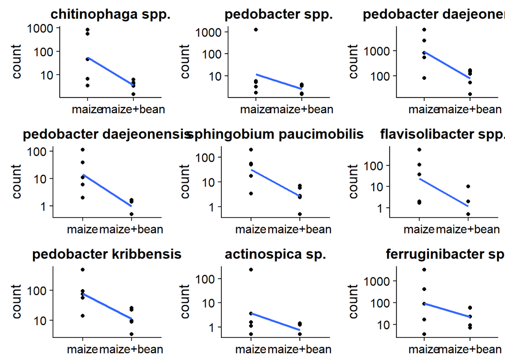

```r
plots.list <- lapply(row.names(otus_maize_hv_s15m6_sigtab_down[order(otus_maize_hv_s15m6_sigtab_down$padj),]),
                     function(x) {
                       d <- plotCounts(mmvsmc_hv_otus_s15m6, x, intgroup=c("culture"), returnData=TRUE)
                       ggplot(d, aes(x=culture, y=count, group=1)) +
                         geom_point() + stat_smooth(se=FALSE,method="loess") + scale_y_log10() +
                         ggtitle(tax[x,"Species"]) +
                         theme(axis.title.x = element_blank(), legend.title=element_blank(), legend.position="top", legend.box="horizontal", legend.key.height = unit(.5, "cm"),legend.text=element_text(size=6))
                     }
)
do.call(grid.arrange,plots.list)
```

Same result that without variance filtering.

## bean_bean-rhizo vs maize+bean_bean-rhizo

```r
bemobeco <- subset_samples(physeq, concom %in% c("bean _ bean-rhizo", "maize+bean _ bean-rhizo"))

bemobeco <- subset_samples(bemobeco, farmer2 %in% c("Ro", "La", "Du", "So"))

meta_data_bemobeco <- bemobeco@sam_data
meta_data_bemobeco <- meta_data_bemobeco[,"condition"]
colnames(meta_data_bemobeco) <- c("culture")
meta_data_bemobeco <- as.data.frame(meta_data_bemobeco)

tax_bemobeco <- as.data.frame(bemobeco@tax_table)
```

### Phylum level

```r
bemobeco_plm <- tax_glom(bemobeco, taxrank = "Phylum")

bean_plm <- bemobeco_plm@otu_table

bean_plm <- as.data.frame (bean_plm)

bean_plm_sup12 <- bean_plm[rowSums(bean_plm) > 12,]

bean_plm_sup12_max5 <- bean_plm_sup12[rowSums(bean_plm_sup12 ==0) <= 5,]

bmvsbc_plm <- DESeqDataSetFromMatrix(bean_plm_sup12_max5,
                                 meta_data_bemobeco,
                                 design = ~ culture)
bmvsbc_plm <- DESeq(bmvsbc_plm)

bmvsbc_plm_res <- results(bmvsbc_plm, cooksCutoff = FALSE)

alpha = 0.05

plm_bean_sigtab = bmvsbc_plm_res[which(bmvsbc_plm_res$padj <= alpha), ]

plm_bean_sigtab
```

```
## log2 fold change (MLE): culture maize.bean vs bean
## Wald test p-value: culture maize.bean vs bean
## DataFrame with 0 rows and 6 columns
```

```r
#No adjusted p-value over 0.05 for positive LogFoldChange
#Down
```

As expected, none of the calculated p-values (adjusted) is above the 5 percents threshold.

##### High variance

```r
bemobeco_plm_highVar0.5 =
  filter_taxa(bemobeco_plm,
              function(x) var(x) > 0.5, TRUE)

bean_plm_highVar0.5 <- as.data.frame (bemobeco_plm_highVar0.5@otu_table)

bean_plm_highVar0.5_sup12 <- bean_plm_highVar0.5[rowSums(bean_plm_highVar0.5) > 12,]

bean_plm_highVar0.5_sup12_max5 <- bean_plm_highVar0.5_sup12[rowSums(bean_plm_highVar0.5_sup12 ==0) <= 5,]

tax_bean_plm_highVar0.5_sup12_max5 <- subset(tax, rownames(tax) %in% rownames(bean_plm_highVar0.5_sup12_max5))

bmvsbc_hv_plm_s12m5 <- DESeqDataSetFromMatrix(bean_plm_highVar0.5_sup12_max5,
                                 meta_data_bemobeco,
                                 design = ~ culture)
bmvsbc_hv_plm_s12m5 <- DESeq(bmvsbc_hv_plm_s12m5)

bmvsbc_hv_plm_s12m5_res <- results(bmvsbc_hv_plm_s12m5, cooksCutoff = FALSE)

alpha = 0.05

plm_bean_hv_s12m5_sigtab = bmvsbc_hv_plm_s12m5_res[which(bmvsbc_hv_plm_s12m5_res$padj <= alpha), ]

plm_bean_hv_s12m5_sigtab
```

```
## log2 fold change (MLE): culture maize.bean vs bean
## Wald test p-value: culture maize.bean vs bean
## DataFrame with 0 rows and 6 columns
```

Same result that without filtering.

### Class level

```r
bemobeco_cls <- tax_glom(bemobeco, taxrank = "Class")

bean_cls <- bemobeco_cls@otu_table

bean_cls <- as.data.frame (bean_cls)

bean_cls_sup12 <- bean_cls[rowSums(bean_cls) > 12,]

bean_cls_sup12_max5 <- bean_cls_sup12[rowSums(bean_cls_sup12 ==0) <= 5,]

bmvsbc_cls <- DESeqDataSetFromMatrix(bean_cls_sup12_max5,
                                 meta_data_bemobeco,
                                 design = ~ culture)
bmvsbc_cls <- DESeq(bmvsbc_cls)

bmvsbc_cls_res <- results(bmvsbc_cls, cooksCutoff = FALSE)

alpha = 0.05

cls_bean_sigtab = bmvsbc_cls_res[which(bmvsbc_cls_res$padj <= alpha), ]

cls_bean_sigtab
```

```
## log2 fold change (MLE): culture maize.bean vs bean
## Wald test p-value: culture maize.bean vs bean
## DataFrame with 0 rows and 6 columns
```

```r
#No adjusted p-value over 0.05 for positive LogFoldChange
#No down
```

Still none of the calculated p-values (adjusted) is above the 5 percents threshold.

##### High variance

```r
bemobeco_cls_highVar0.5 =
  filter_taxa(bemobeco_cls,
              function(x) var(x) > 0.5, TRUE)

bean_cls_highVar0.5 <- as.data.frame (bemobeco_cls_highVar0.5@otu_table)

bean_cls_highVar0.5_sup12 <- bean_cls_highVar0.5[rowSums(bean_cls_highVar0.5) > 12,]

bean_cls_highVar0.5_sup12_max5 <- bean_cls_highVar0.5_sup12[rowSums(bean_cls_highVar0.5_sup12 ==0) <= 5,]

bmvsbc_hv_cls_s12m5 <- DESeqDataSetFromMatrix(bean_cls_highVar0.5_sup12_max5,
                                 meta_data_bemobeco,
                                 design = ~ culture)
bmvsbc_hv_cls_s12m5 <- DESeq(bmvsbc_hv_cls_s12m5)

bmvsbc_hv_cls_s12m5_res <- results(bmvsbc_hv_cls_s12m5, cooksCutoff = FALSE)

alpha = 0.05

cls_bean_hv_s12m5_sigtab = bmvsbc_hv_cls_s12m5_res[which(bmvsbc_hv_cls_s12m5_res$padj <= alpha), ]

cls_bean_hv_s12m5_sigtab
```

```
## log2 fold change (MLE): culture maize.bean vs bean
## Wald test p-value: culture maize.bean vs bean
## DataFrame with 0 rows and 6 columns
```

Same result that without filtering.

### Order level

```r
bemobeco_odr <- tax_glom(bemobeco, taxrank = "Order")

bean_odr <- bemobeco_odr@otu_table

bean_odr <- as.data.frame (bean_odr)

bean_odr_sup12 <- bean_odr[rowSums(bean_odr) > 12,]

bean_odr_sup12_max5 <- bean_odr_sup12[rowSums(bean_odr_sup12 ==0) <= 5,]

bmvsbc_odr <- DESeqDataSetFromMatrix(bean_odr_sup12_max5,
                                 meta_data_bemobeco,
                                 design = ~ culture)
bmvsbc_odr <- DESeq(bmvsbc_odr)

bmvsbc_odr_res <- results(bmvsbc_odr, cooksCutoff = FALSE)

alpha = 0.05

odr_bean_sigtab = bmvsbc_odr_res[which(bmvsbc_odr_res$padj <= alpha), ]

odr_bean_sigtab
```

```
## log2 fold change (MLE): culture maize.bean vs bean
## Wald test p-value: culture maize.bean vs bean
## DataFrame with 1 row and 6 columns
##        baseMean log2FoldChange     lfcSE      stat       pvalue       padj
##       <numeric>      <numeric> <numeric> <numeric>    <numeric>  <numeric>
## OTU33  453.3677      -6.483297  1.787419 -3.627184 0.0002865295 0.02578765
```

```r
#No adjusted p-value over 0.05 for positive LogFoldChange
#Down

odr_bean_sigtab_down <- odr_bean_sigtab[which(odr_bean_sigtab@listData$log2FoldChange < 0),]

cbind(head(odr_bean_sigtab_down[order(odr_bean_sigtab_down$padj),]), tax[row.names(head(odr_bean_sigtab_down[order(odr_bean_sigtab_down$padj),])),2:7])
```

```
## DataFrame with 1 row and 12 columns
##        baseMean log2FoldChange     lfcSE      stat       pvalue       padj
##       <numeric>      <numeric> <numeric> <numeric>    <numeric>  <numeric>
## OTU33  453.3677      -6.483297  1.787419 -3.627184 0.0002865295 0.02578765
##               Phylum               Class       Order       Family    Genus
##             <factor>            <factor>    <factor>     <factor> <factor>
## OTU33 proteobacteria gammaproteobacteria vibrionales vibrionaceae   vibrio
##          Species
##         <factor>
## OTU33 vibrio sp.
```

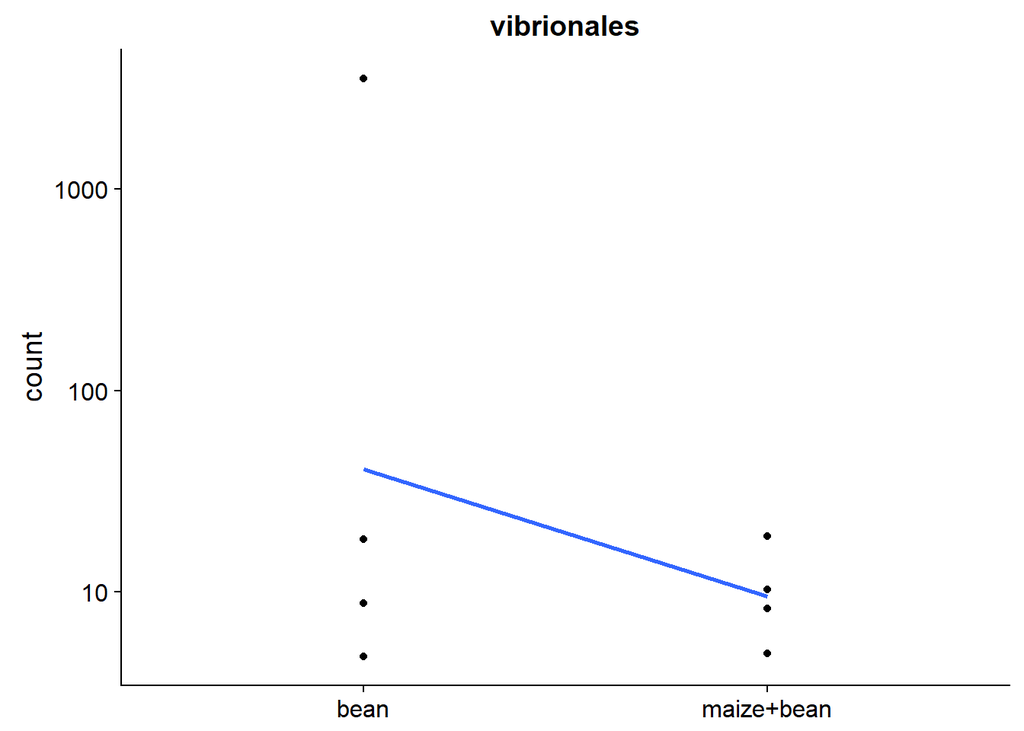

```r
plots.list <- lapply(row.names(head(odr_bean_sigtab_down[order(odr_bean_sigtab_down$padj),])),
                     function(x) {
                       d <- plotCounts(bmvsbc_odr, x, intgroup=c("culture"), returnData=TRUE)
                       ggplot(d, aes(x=culture, y=count, group=1)) +
                         geom_point() + stat_smooth(se=FALSE,method="loess") + scale_y_log10() +
                         ggtitle(tax[x,"Order"]) +
                         theme(axis.title.x = element_blank(), legend.title=element_blank(), legend.position="top", legend.box="horizontal", legend.key.height = unit(.5, "cm"),legend.text=element_text(size=6))
                     }
)
do.call(grid.arrange,plots.list)
```

```r
be_or <- tax_glom(physeq, taxrank = "Order")
be_or <- subset_samples(be_or, condition != "maize")
be_or <- subset_samples(be_or, compartment != "maize-rhizo")
be_or_concom <- merge_samples(be_or, "concom")
be_or_concom@sam_data$concom = c("bean _ bean-rhizo", "bean _ bulk", "maize+bean _ bean-rhizo", "maize+bean _ bulk")

be_or_concom_vi <- subset_taxa(be_or_concom,Order =="vibrionales")
```

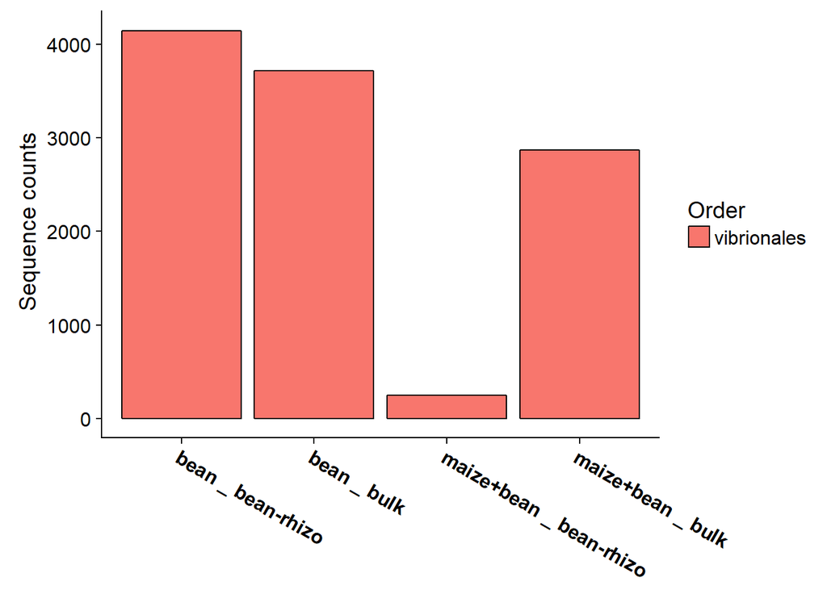

```r
be_or_concom_vi %>%
  plot_bar(fill = "Order",
         x = "concom")+
  theme(axis.text.x = element_text(angle = 330, size = 12, face = "bold"),
        axis.title.x = element_blank())+
  ylab(label = " Sequence counts")
```

```r
ma_or <- tax_glom(physeq, taxrank = "Order")
ma_or <- subset_samples(ma_or, condition != "bean")
ma_or <- subset_samples(ma_or, compartment != "bean-rhizo")
ma_or_concom <- merge_samples(ma_or, "concom")
ma_or_concom@sam_data$concom = c("maize _ bulk", "maize _ maize-rhizo", "maize+bean _ bulk", "maize+bean _ maize-rhizo")

ma_or_concom_vi <- subset_taxa(ma_or_concom,Order =="vibrionales")
```

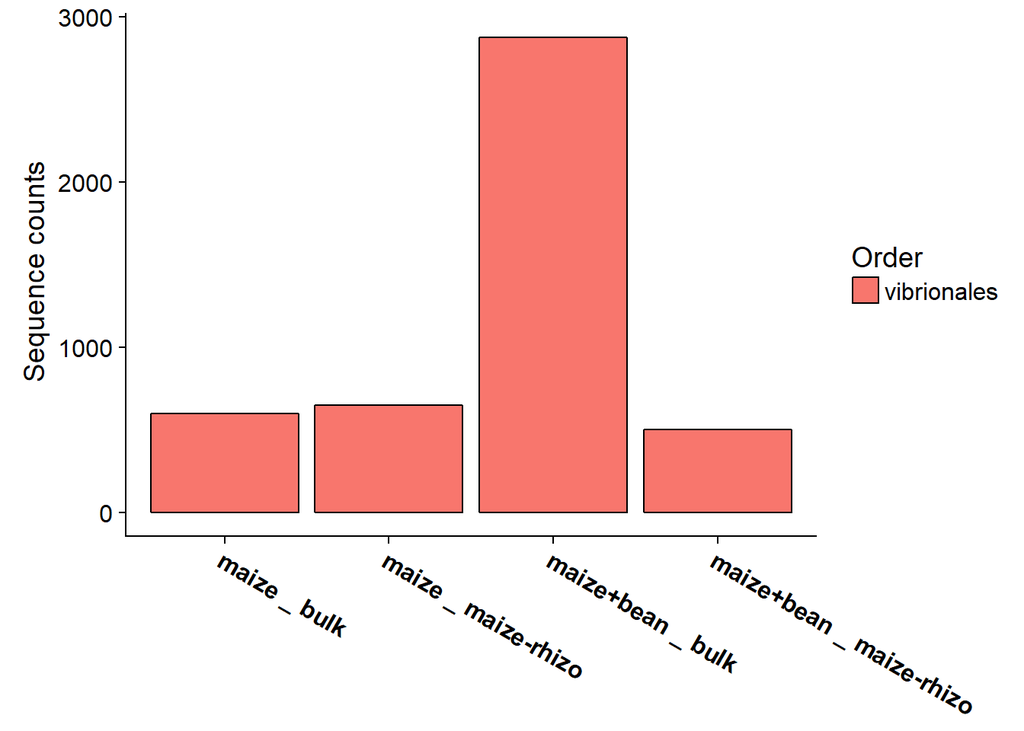

```r
ma_or_concom_vi %>%
  plot_bar(fill = "Order",
         x = "concom")+
  theme(axis.text.x = element_text(angle = 330, size = 12, face = "bold"),
        axis.title.x = element_blank())+
  ylab(label = " Sequence counts")
```

The *Vibrionales* order shows interesting features here. Within the monoculture bean rhizosphere and the corresponding bulk soil, its abundance is quite important. Under polyculture treatment, this abundance strongly decreases within the bean rhizosphere compartment but not within the bulk soil. Concurrently, this OTU abundance was quite low either within maize rhizosphere (monoculture and polyculture) and monoculture bulk soil. Hence, somehow, polyculture with maize could have a negative impact on this OTU abundance within the bean rhizosphere compartment.

##### High variance

```r
bemobeco_odr_highVar0.5 =
  filter_taxa(bemobeco_odr,
              function(x) var(x) > 0.5, TRUE)

bean_odr_highVar0.5 <- as.data.frame (bemobeco_odr_highVar0.5@otu_table)

bean_odr_highVar0.5_sup12 <- bean_odr_highVar0.5[rowSums(bean_odr_highVar0.5) > 12,]

bean_odr_highVar0.5_sup12_max5 <- bean_odr_highVar0.5_sup12[rowSums(bean_odr_highVar0.5_sup12 ==0) <= 5,]

bmvsbc_hv_odr_s12m5 <- DESeqDataSetFromMatrix(bean_odr_highVar0.5_sup12_max5,
                                 meta_data_bemobeco,
                                 design = ~ culture)
bmvsbc_hv_odr_s12m5 <- DESeq(bmvsbc_hv_odr_s12m5)

bmvsbc_hv_odr_s12m5_res <- results(bmvsbc_hv_odr_s12m5, cooksCutoff = FALSE)

alpha = 0.05

odr_bean_hv_s12m5_sigtab = bmvsbc_hv_odr_s12m5_res[which(bmvsbc_hv_odr_s12m5_res$padj <= alpha), ]

odr_bean_hv_s12m5_sigtab
```

```
## log2 fold change (MLE): culture maize.bean vs bean
## Wald test p-value: culture maize.bean vs bean
## DataFrame with 1 row and 6 columns
##        baseMean log2FoldChange     lfcSE      stat       pvalue       padj
##       <numeric>      <numeric> <numeric> <numeric>    <numeric>  <numeric>
## OTU33  453.3677      -6.483297  1.787419 -3.627184 0.0002865295 0.02578765
```

```r
odr_bean_hv_s12m5_sigtab_down <- odr_bean_hv_s12m5_sigtab[which(odr_bean_hv_s12m5_sigtab@listData$log2FoldChange < 0),]

cbind(head(odr_bean_hv_s12m5_sigtab_down[order(odr_bean_hv_s12m5_sigtab_down$padj),]), tax[row.names(head(odr_bean_hv_s12m5_sigtab_down[order(odr_bean_hv_s12m5_sigtab_down$padj),])),2:7])
```

```
## DataFrame with 1 row and 12 columns
##        baseMean log2FoldChange     lfcSE      stat       pvalue       padj
##       <numeric>      <numeric> <numeric> <numeric>    <numeric>  <numeric>
## OTU33  453.3677      -6.483297  1.787419 -3.627184 0.0002865295 0.02578765
##               Phylum               Class       Order       Family    Genus
##             <factor>            <factor>    <factor>     <factor> <factor>
## OTU33 proteobacteria gammaproteobacteria vibrionales vibrionaceae   vibrio
##          Species
##         <factor>
## OTU33 vibrio sp.
```

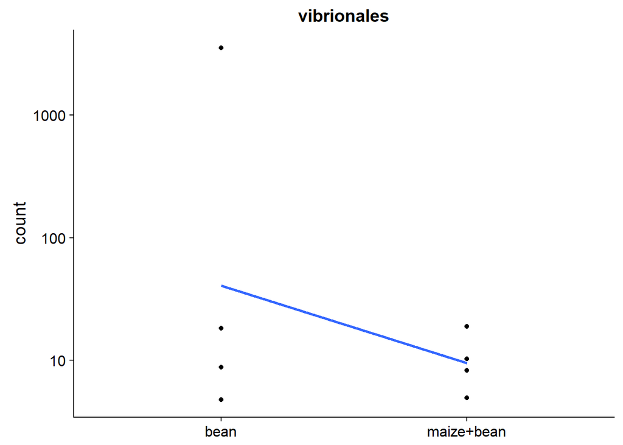

```r
plots.list <- lapply(row.names(head(odr_bean_hv_s12m5_sigtab_down[order(odr_bean_hv_s12m5_sigtab_down$padj),])),
                     function(x) {
                       d <- plotCounts(bmvsbc_hv_odr_s12m5, x, intgroup=c("culture"), returnData=TRUE)
                       ggplot(d, aes(x=culture, y=count, group=1)) +
                         geom_point() + stat_smooth(se=FALSE,method="loess") + scale_y_log10() +
                         ggtitle(tax[x,"Order"]) +
                         theme(axis.title.x = element_blank(), legend.title=element_blank(), legend.position="top", legend.box="horizontal", legend.key.height = unit(.5, "cm"),legend.text=element_text(size=6))
                     }
)
do.call(grid.arrange,plots.list)
```

Same result that without variance filtering.

### Family level

```r
bemobeco_fmy <- tax_glom(bemobeco, taxrank = "Family")

bean_fmy <- bemobeco_fmy@otu_table

bean_fmy <- as.data.frame (bean_fmy)

bean_fmy_sup12 <- bean_fmy[rowSums(bean_fmy) > 12,]

bean_fmy_sup12_max5 <- bean_fmy_sup12[rowSums(bean_fmy_sup12 ==0) <= 5,]

bmvsbc_fmy <- DESeqDataSetFromMatrix(bean_fmy_sup12_max5,
                                 meta_data_bemobeco,
                                 design = ~ culture)
bmvsbc_fmy <- DESeq(bmvsbc_fmy)

bmvsbc_fmy_res <- results(bmvsbc_fmy, cooksCutoff = FALSE)

alpha = 0.05

fmy_bean_sigtab = bmvsbc_fmy_res[which(bmvsbc_fmy_res$padj <= alpha), ]

fmy_bean_sigtab
```

```
## log2 fold change (MLE): culture maize.bean vs bean
## Wald test p-value: culture maize.bean vs bean
## DataFrame with 2 rows and 6 columns
##          baseMean log2FoldChange     lfcSE      stat       pvalue
##         <numeric>      <numeric> <numeric> <numeric>    <numeric>
## OTU33    438.0672      -6.473793  1.784611 -3.627566 0.0002861057
## OTU7443  110.3173      -4.269887  1.174863 -3.634371 0.0002786601
##               padj
##          <numeric>
## OTU33   0.02818141
## OTU7443 0.02818141
```

```r
#No adjusted p-value over 0.05 for positive LogFoldChange
#Down

fmy_bean_sigtab_down <- fmy_bean_sigtab[which(fmy_bean_sigtab@listData$log2FoldChange < 0),]

cbind(head(fmy_bean_sigtab_down[order(fmy_bean_sigtab_down$padj),]), tax[row.names(head(fmy_bean_sigtab_down[order(fmy_bean_sigtab_down$padj),])),2:7])
```

```
## DataFrame with 2 rows and 12 columns
##          baseMean log2FoldChange     lfcSE      stat       pvalue
##         <numeric>      <numeric> <numeric> <numeric>    <numeric>
## OTU33    438.0672      -6.473793  1.784611 -3.627566 0.0002861057
## OTU7443  110.3173      -4.269887  1.174863 -3.634371 0.0002786601
##               padj         Phylum               Class           Order
##          <numeric>       <factor>            <factor>        <factor>
## OTU33   0.02818141 proteobacteria gammaproteobacteria     vibrionales
## OTU7443 0.02818141 proteobacteria gammaproteobacteria pseudomonadales
##                Family         Genus            Species
##              <factor>      <factor>           <factor>
## OTU33    vibrionaceae        vibrio         vibrio sp.
## OTU7443 moraxellaceae acinetobacter acinetobacter spp.
```

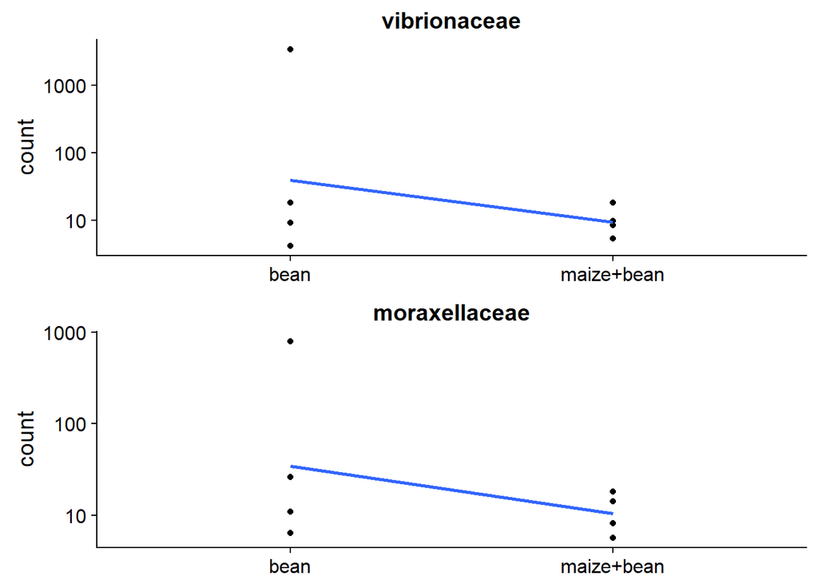

```r
plots.list <- lapply(row.names(head(fmy_bean_sigtab_down[order(fmy_bean_sigtab_down$padj),])),
                     function(x) {
                       d <- plotCounts(bmvsbc_fmy, x, intgroup=c("culture"), returnData=TRUE)
                       ggplot(d, aes(x=culture, y=count, group=1)) +
                         geom_point() + stat_smooth(se=FALSE,method="loess") + scale_y_log10() +
                         ggtitle(tax[x,"Family"]) +
                         theme(axis.title.x = element_blank(), legend.title=element_blank(), legend.position="top", legend.box="horizontal", legend.key.height = unit(.5, "cm"),legend.text=element_text(size=6))
                     }
)
do.call(grid.arrange,plots.list)
```

```r
be_fa <- tax_glom(physeq, taxrank = "Family")
be_fa <- subset_samples(be_fa, condition != "maize")
be_fa <- subset_samples(be_fa, compartment != "maize-rhizo")
be_fa_concom <- merge_samples(be_fa, "concom")
be_fa_concom@sam_data$concom = c("bean _ bean-rhizo", "bean _ bulk", "maize+bean _ bean-rhizo", "maize+bean _ bulk")

be_fa_concom_vi <- subset_taxa(be_fa_concom,Family =="vibrionaceae")
```

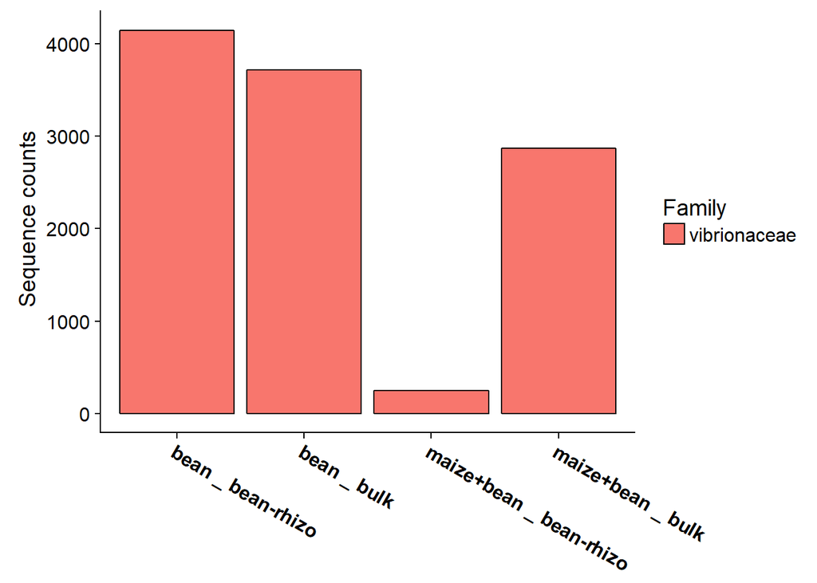

```r
be_fa_concom_vi %>%
  plot_bar(fill = "Family",
         x = "concom")+
  theme(axis.text.x = element_text(angle = 330, size = 12, face = "bold"),
        axis.title.x = element_blank())+
  ylab(label = " Sequence counts")
```

```r
ma_fa <- tax_glom(physeq, taxrank = "Family")
ma_fa <- subset_samples(ma_fa, condition != "bean")
ma_fa <- subset_samples(ma_fa, compartment != "bean-rhizo")
ma_fa_concom <- merge_samples(ma_fa, "concom")
ma_fa_concom@sam_data$concom = c("maize _ bulk", "maize _ maize-rhizo", "maize+bean _ bulk", "maize+bean _ maize-rhizo")

ma_fa_concom_vi <- subset_taxa(ma_fa_concom,Family =="vibrionaceae")
```

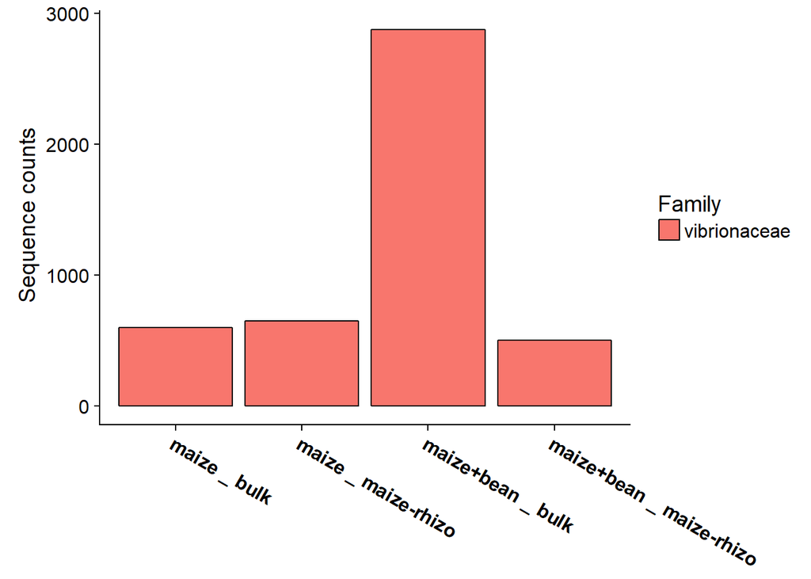

```r
ma_fa_concom_vi %>%
  plot_bar(fill = "Family",
         x = "concom")+
  theme(axis.text.x = element_text(angle = 330, size = 12, face = "bold"),
        axis.title.x = element_blank())+
  ylab(label = " Sequence counts")
```

Same result that for the *Vibrionales* order.

```r
be_fa_concom_mi <- subset_taxa(be_fa_concom,Family =="moraxellaceae")
```

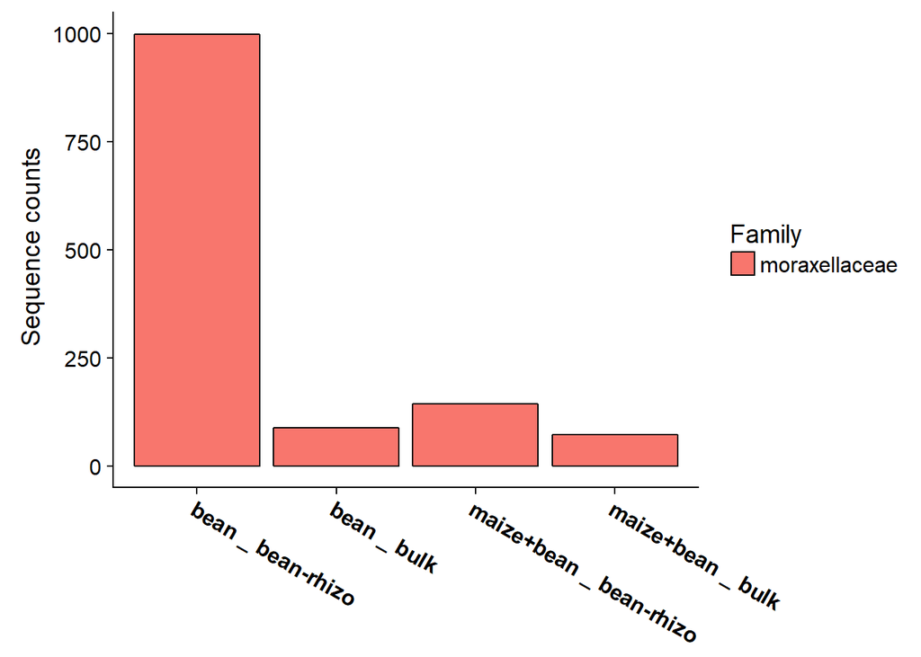

```r
be_fa_concom_mi %>%
  plot_bar(fill = "Family",
         x = "concom")+
  theme(axis.text.x = element_text(angle = 330, size = 12, face = "bold"),
        axis.title.x = element_blank())+
  ylab(label = " Sequence counts")
```

```r
ma_fa_concom_mi <- subset_taxa(ma_fa_concom,Family =="moraxellaceae")
```

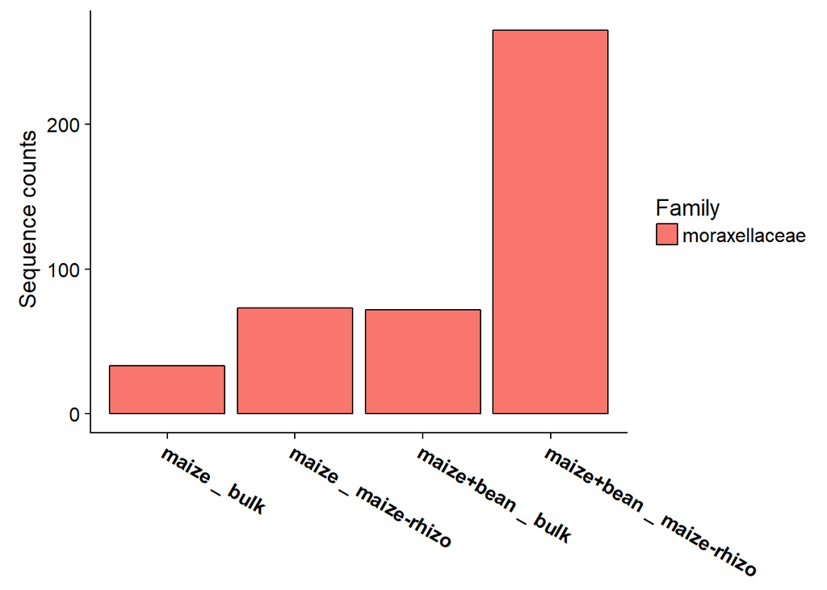

```r
ma_fa_concom_mi %>%
  plot_bar(fill = "Family",
         x = "concom")+
  theme(axis.text.x = element_text(angle = 330, size = 12, face = "bold"),
        axis.title.x = element_blank())+
  ylab(label = " Sequence counts")
```

This shows another possible example of maize-bean polyculture impact on the bean rhizo-microbiome. Under bean monoculture condition, the *Moraxellaceae* family abundance is of an order of magnitude higher within rhizosphere compartment than within bulk soil. Under polyculture condition, this family abundance within the bulk soil is quite similar to the monoculture bulk soil. But clearly lower within the bean rhizosphere than within monoculture bean rhizosphere. About maize rhizosphere, the abundance of this family is higher than within the bulk soil, either under mono and polyculture conditions, but the difference between maize rhizosphere and bulk soil is higher under polyculture condition than under monoculture condition. Hence, here maize-bean polyculture decreased the *Moraxellaceae* family abundance within bean rhizosphere, relatively to monoculture, but increased it within maize rhizosphere.

##### High variance

```r
bemobeco_fmy_highVar0.5 =
  filter_taxa(bemobeco_fmy,
              function(x) var(x) > 0.5, TRUE)

bean_fmy_highVar0.5 <- as.data.frame (bemobeco_fmy_highVar0.5@otu_table)

bean_fmy_highVar0.5_sup12 <- bean_fmy_highVar0.5[rowSums(bean_fmy_highVar0.5) > 12,]

bean_fmy_highVar0.5_sup12_max5 <- bean_fmy_highVar0.5_sup12[rowSums(bean_fmy_highVar0.5_sup12 ==0) <= 5,]

bmvsbc_hv_fmy_s12m5 <- DESeqDataSetFromMatrix(bean_fmy_highVar0.5_sup12_max5,
                                 meta_data_bemobeco,
                                 design = ~ culture)
bmvsbc_hv_fmy_s12m5 <- DESeq(bmvsbc_hv_fmy_s12m5)

bmvsbc_hv_fmy_s12m5_res <- results(bmvsbc_hv_fmy_s12m5, cooksCutoff = FALSE)

alpha = 0.05

fmy_bean_hv_s12m5_sigtab = bmvsbc_hv_fmy_s12m5_res[which(bmvsbc_hv_fmy_s12m5_res$padj <= alpha), ]

fmy_bean_hv_s12m5_sigtab
```

```
## log2 fold change (MLE): culture maize.bean vs bean
## Wald test p-value: culture maize.bean vs bean
## DataFrame with 2 rows and 6 columns
##          baseMean log2FoldChange     lfcSE      stat       pvalue
##         <numeric>      <numeric> <numeric> <numeric>    <numeric>
## OTU33    438.0672      -6.473793  1.784611 -3.627566 0.0002861057
## OTU7443  110.3173      -4.269887  1.174863 -3.634371 0.0002786601
##               padj
##          <numeric>
## OTU33   0.02818141
## OTU7443 0.02818141
```

```r
fmy_bean_hv_s12m5_sigtab_down <- fmy_bean_hv_s12m5_sigtab[which(fmy_bean_hv_s12m5_sigtab@listData$log2FoldChange < 0),]

cbind(head(fmy_bean_hv_s12m5_sigtab_down[order(fmy_bean_hv_s12m5_sigtab_down$padj),]), tax[row.names(head(fmy_bean_hv_s12m5_sigtab_down[order(fmy_bean_hv_s12m5_sigtab_down$padj),])),2:7])
```

```
## DataFrame with 2 rows and 12 columns
##          baseMean log2FoldChange     lfcSE      stat       pvalue
##         <numeric>      <numeric> <numeric> <numeric>    <numeric>
## OTU33    438.0672      -6.473793  1.784611 -3.627566 0.0002861057
## OTU7443  110.3173      -4.269887  1.174863 -3.634371 0.0002786601
##               padj         Phylum               Class           Order
##          <numeric>       <factor>            <factor>        <factor>
## OTU33   0.02818141 proteobacteria gammaproteobacteria     vibrionales
## OTU7443 0.02818141 proteobacteria gammaproteobacteria pseudomonadales
##                Family         Genus            Species
##              <factor>      <factor>           <factor>
## OTU33    vibrionaceae        vibrio         vibrio sp.
## OTU7443 moraxellaceae acinetobacter acinetobacter spp.
```

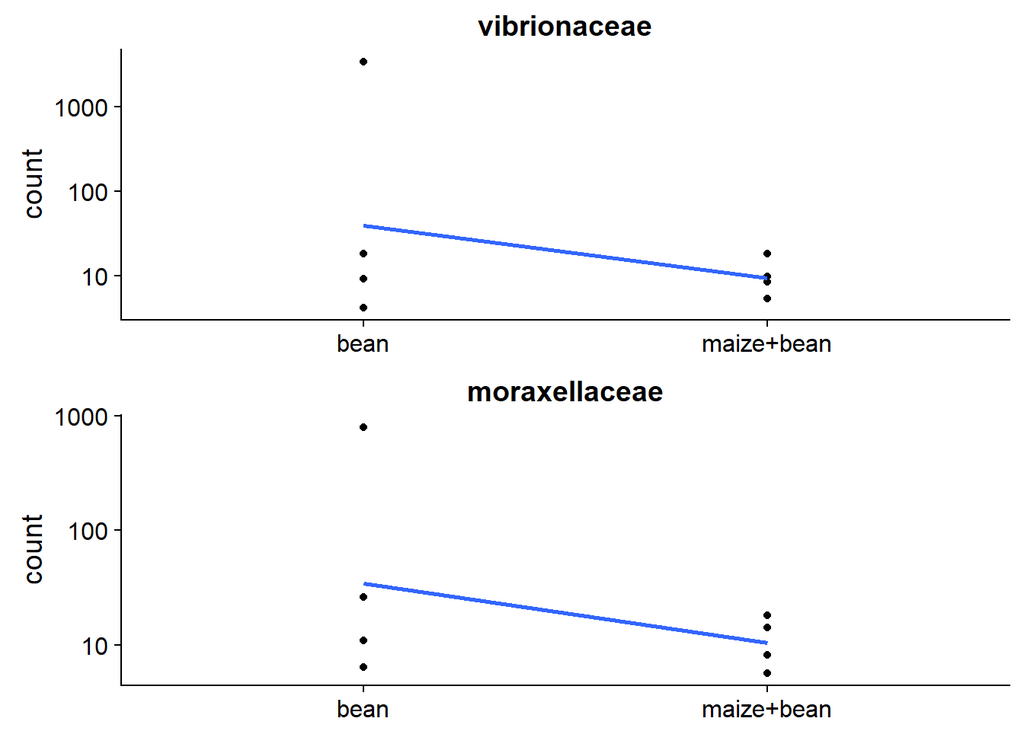

```r
plots.list <- lapply(row.names(head(fmy_bean_hv_s12m5_sigtab_down[order(fmy_bean_hv_s12m5_sigtab_down$padj),])),
                     function(x) {
                       d <- plotCounts(bmvsbc_hv_fmy_s12m5, x, intgroup=c("culture"), returnData=TRUE)
                       ggplot(d, aes(x=culture, y=count, group=1)) +
                         geom_point() + stat_smooth(se=FALSE,method="loess") + scale_y_log10() +
                         ggtitle(tax[x,"Family"]) +
                         theme(axis.title.x = element_blank(), legend.title=element_blank(), legend.position="top", legend.box="horizontal", legend.key.height = unit(.5, "cm"),legend.text=element_text(size=6))
                     }
)
do.call(grid.arrange,plots.list)
```

Same result that without variance filtering.

### Genus level

```r
bemobeco_gns <- tax_glom(bemobeco, taxrank = "Genus")

bean_gns <- bemobeco_gns@otu_table

bean_gns <- as.data.frame (bean_gns)

bean_gns_sup12 <- bean_gns[rowSums(bean_gns) > 100,]

bean_gns_sup12_max5 <- bean_gns_sup12[rowSums(bean_gns_sup12 ==0) == 0,]

bmvsbc_gns <- DESeqDataSetFromMatrix(bean_gns_sup12_max5,
                                 meta_data_bemobeco,
                                 design = ~ culture)
bmvsbc_gns <- DESeq(bmvsbc_gns)

bmvsbc_gns_res <- results(bmvsbc_gns, cooksCutoff = FALSE)

alpha = 0.05

gns_bean_sigtab = bmvsbc_gns_res[which(bmvsbc_gns_res$padj <= alpha), ]

gns_bean_sigtab
```

```
## log2 fold change (MLE): culture maize.bean vs bean
## Wald test p-value: culture maize.bean vs bean
## DataFrame with 2 rows and 6 columns
##          baseMean log2FoldChange     lfcSE      stat       pvalue
##         <numeric>      <numeric> <numeric> <numeric>    <numeric>
## OTU33    430.2271      -6.454402  1.443592 -4.471069 7.782942e-06
## OTU7443  108.2111      -4.384038  1.226218 -3.575253 3.498897e-04
##                padj
##           <numeric>
## OTU33   0.002101394
## OTU7443 0.047235109
```

```r
#No adjusted p-value over 0.05 for positive LogFoldChange
#Down

gns_bean_sigtab_down <- gns_bean_sigtab[which(gns_bean_sigtab@listData$log2FoldChange < 0),]

cbind(head(gns_bean_sigtab_down[order(gns_bean_sigtab_down$padj),]), tax[row.names(head(gns_bean_sigtab_down[order(gns_bean_sigtab_down$padj),])),2:7])
```

```
## DataFrame with 2 rows and 12 columns
##          baseMean log2FoldChange     lfcSE      stat       pvalue
##         <numeric>      <numeric> <numeric> <numeric>    <numeric>
## OTU33    430.2271      -6.454402  1.443592 -4.471069 7.782942e-06
## OTU7443  108.2111      -4.384038  1.226218 -3.575253 3.498897e-04
##                padj         Phylum               Class           Order
##           <numeric>       <factor>            <factor>        <factor>
## OTU33   0.002101394 proteobacteria gammaproteobacteria     vibrionales
## OTU7443 0.047235109 proteobacteria gammaproteobacteria pseudomonadales
##                Family         Genus            Species
##              <factor>      <factor>           <factor>
## OTU33    vibrionaceae        vibrio         vibrio sp.
## OTU7443 moraxellaceae acinetobacter acinetobacter spp.
```

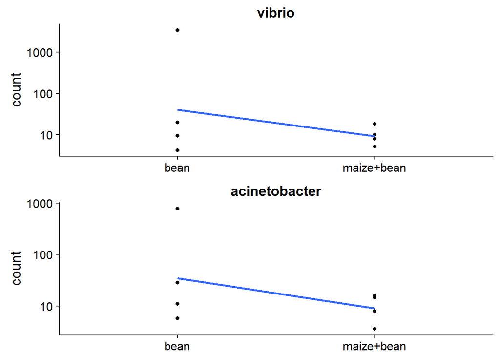

```r
plots.list <- lapply(row.names(head(gns_bean_sigtab_down[order(gns_bean_sigtab_down$padj),])),
                     function(x) {
                       d <- plotCounts(bmvsbc_gns, x, intgroup=c("culture"), returnData=TRUE)
                       ggplot(d, aes(x=culture, y=count, group=1)) +
                         geom_point() + stat_smooth(se=FALSE,method="loess") + scale_y_log10() +
                         ggtitle(tax[x,"Genus"]) +
                         theme(axis.title.x = element_blank(), legend.title=element_blank(), legend.position="top", legend.box="horizontal", legend.key.height = unit(.5, "cm"),legend.text=element_text(size=6))
                     }
)
do.call(grid.arrange,plots.list)
```

```r
be_ge <- tax_glom(physeq, taxrank = "Genus")
be_ge <- subset_samples(be_ge, condition != "maize")
be_ge <- subset_samples(be_ge, compartment != "maize-rhizo")
be_ge_concom <- merge_samples(be_ge, "concom")
be_ge_concom@sam_data$concom = c("bean _ bean-rhizo", "bean _ bulk", "maize+bean _ bean-rhizo", "maize+bean _ bulk")

be_ge_concom_vi <- subset_taxa(be_ge_concom,Genus =="vibrio")
```

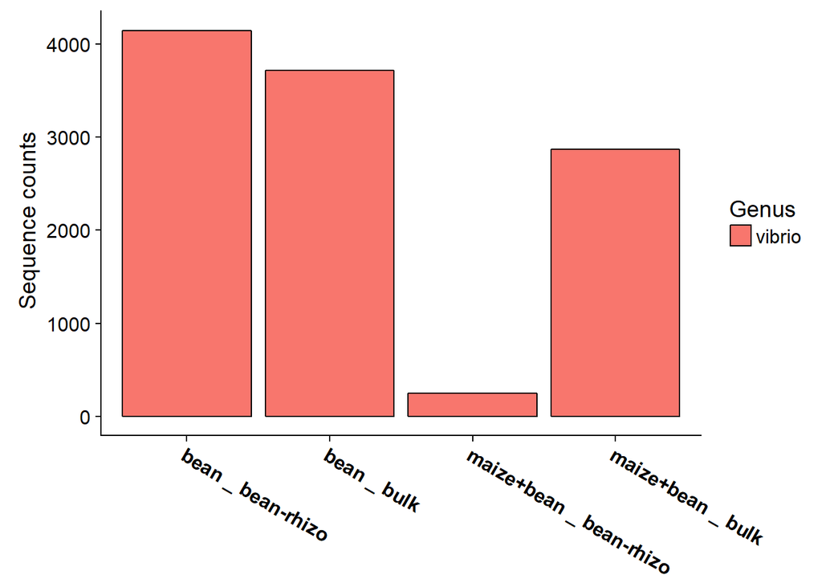

```r
be_ge_concom_vi %>%
  plot_bar(fill = "Genus",
         x = "concom")+
  theme(axis.text.x = element_text(angle = 330, size = 12, face = "bold"),
        axis.title.x = element_blank())+
  ylab(label = " Sequence counts")
```

```r
ma_ge <- tax_glom(physeq, taxrank = "Genus")
ma_ge <- subset_samples(ma_ge, condition != "bean")
ma_ge <- subset_samples(ma_ge, compartment != "bean-rhizo")
ma_ge_concom <- merge_samples(ma_ge, "concom")
ma_ge_concom@sam_data$concom = c("maize _ bulk", "maize _ maize-rhizo", "maize+bean _ bulk", "maize+bean _ maize-rhizo")

ma_ge_concom_vi <- subset_taxa(ma_ge_concom,Genus =="vibrio")
```

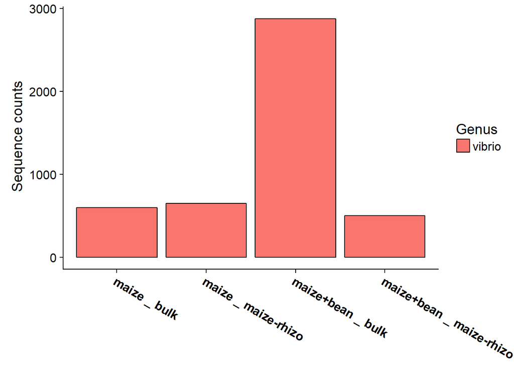

```r
ma_ge_concom_vi %>%
  plot_bar(fill = "Genus",
         x = "concom")+
  theme(axis.text.x = element_text(angle = 330, size = 12, face = "bold"),
        axis.title.x = element_blank())+
  ylab(label = " Sequence counts")
```

Same result that for the *Vibrionales* order.

```r
be_ge_concom_mi <- subset_taxa(be_ge_concom,Genus =="acinetobacter")
```

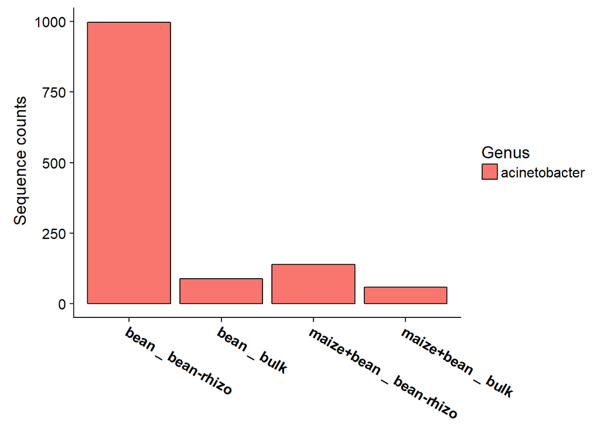

```r
be_ge_concom_mi %>%
  plot_bar(fill = "Genus",
         x = "concom")+
  theme(axis.text.x = element_text(angle = 330, size = 12, face = "bold"),
        axis.title.x = element_blank())+
  ylab(label = " Sequence counts")
```

```r
ma_ge_concom_mi <- subset_taxa(ma_ge_concom,Genus =="acinetobacter")
```

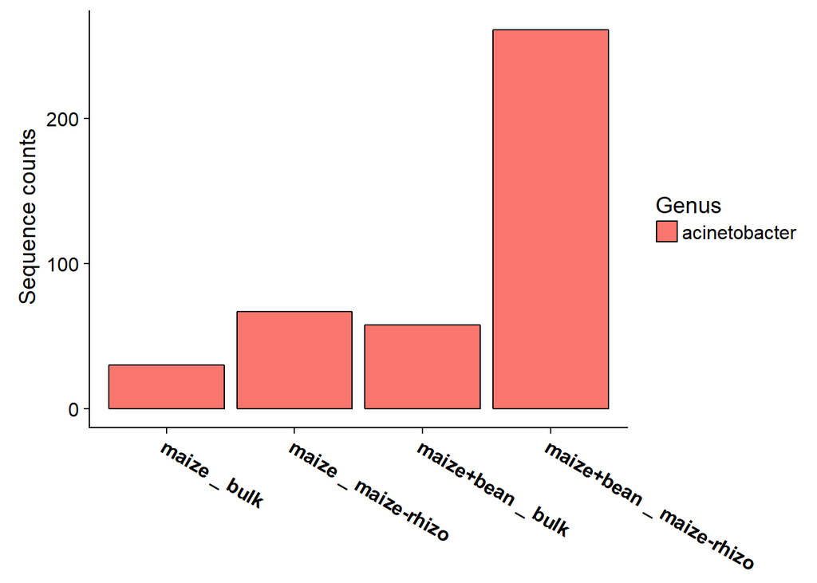

```r
ma_ge_concom_mi %>%
  plot_bar(fill = "Genus",
         x = "concom")+
  theme(axis.text.x = element_text(angle = 330, size = 12, face = "bold"),
        axis.title.x = element_blank())+
  ylab(label = " Sequence counts")
```

Same result that for the *Moraxellaceae* family.

##### High variance

```r
bemobeco_gns_highVar0.5 =
  filter_taxa(bemobeco_gns,
              function(x) var(x) > 0.5, TRUE)

bean_gns_highVar0.5 <- as.data.frame (bemobeco_gns_highVar0.5@otu_table)

bean_gns_highVar0.5_sup12 <- bean_gns_highVar0.5[rowSums(bean_gns_highVar0.5) > 12,]

bean_gns_highVar0.5_sup12_max5 <- bean_gns_highVar0.5_sup12[rowSums(bean_gns_highVar0.5_sup12 ==0) <= 5,]

bmvsbc_hv_gns_s12m5 <- DESeqDataSetFromMatrix(bean_gns_highVar0.5_sup12_max5,
                                 meta_data_bemobeco,
                                 design = ~ culture)
bmvsbc_hv_gns_s12m5 <- DESeq(bmvsbc_hv_gns_s12m5)

bmvsbc_hv_gns_s12m5_res <- results(bmvsbc_hv_gns_s12m5, cooksCutoff = FALSE)

alpha = 0.05

gns_bean_hv_s12m5_sigtab = bmvsbc_hv_gns_s12m5_res[which(bmvsbc_hv_gns_s12m5_res$padj <= alpha), ]

gns_bean_hv_s12m5_sigtab
```

```
## log2 fold change (MLE): culture maize.bean vs bean
## Wald test p-value: culture maize.bean vs bean
## DataFrame with 1 row and 6 columns
##        baseMean log2FoldChange     lfcSE      stat       pvalue
##       <numeric>      <numeric> <numeric> <numeric>    <numeric>
## OTU33  444.9022      -6.504114  1.506856 -4.316347 1.586326e-05
##              padj
##         <numeric>
## OTU33 0.007804722
```

```r
gns_bean_hv_s12m5_sigtab_down <- gns_bean_hv_s12m5_sigtab[which(gns_bean_hv_s12m5_sigtab@listData$log2FoldChange < 0),]

cbind(head(gns_bean_hv_s12m5_sigtab_down[order(gns_bean_hv_s12m5_sigtab_down$padj),]), tax[row.names(head(gns_bean_hv_s12m5_sigtab_down[order(gns_bean_hv_s12m5_sigtab_down$padj),])),2:7])
```

```
## DataFrame with 1 row and 12 columns
##        baseMean log2FoldChange     lfcSE      stat       pvalue
##       <numeric>      <numeric> <numeric> <numeric>    <numeric>
## OTU33  444.9022      -6.504114  1.506856 -4.316347 1.586326e-05
##              padj         Phylum               Class       Order
##         <numeric>       <factor>            <factor>    <factor>
## OTU33 0.007804722 proteobacteria gammaproteobacteria vibrionales
##             Family    Genus    Species
##           <factor> <factor>   <factor>
## OTU33 vibrionaceae   vibrio vibrio sp.
```

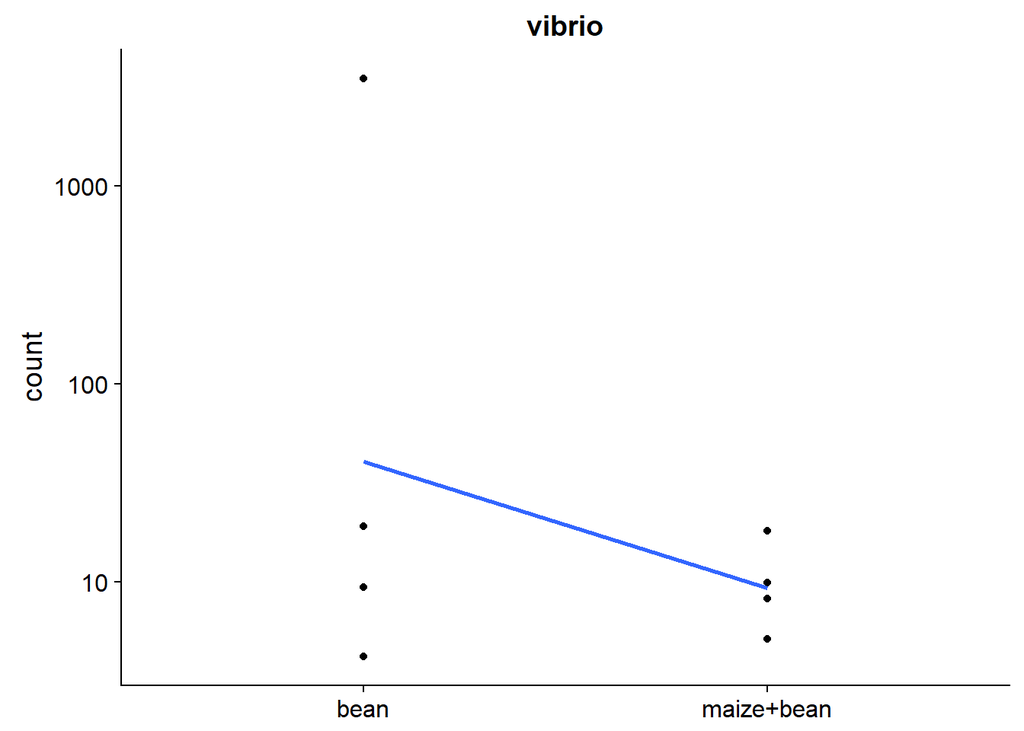

```r
plots.list <- lapply(row.names(head(gns_bean_hv_s12m5_sigtab_down[order(gns_bean_hv_s12m5_sigtab_down$padj),])),
                     function(x) {
                       d <- plotCounts(bmvsbc_hv_gns_s12m5, x, intgroup=c("culture"), returnData=TRUE)
                       ggplot(d, aes(x=culture, y=count, group=1)) +
                         geom_point() + stat_smooth(se=FALSE,method="loess") + scale_y_log10() +
                         ggtitle(tax[x,"Genus"]) +
                         theme(axis.title.x = element_blank(), legend.title=element_blank(), legend.position="top", legend.box="horizontal", legend.key.height = unit(.5, "cm"),legend.text=element_text(size=6))
                     }
)
do.call(grid.arrange,plots.list)
```

Here, the *Acinetobacter* genus was filtered because of its too low variance, but it didn’t allow more adjusted p-values to get above the 5 percent threshold. Besides this, the result is the same that without filtering.

### Species level

```r
bemobeco_sps <- tax_glom(bemobeco, taxrank = "Species")

bean_sps <- bemobeco_sps@otu_table

bean_sps <- as.data.frame (bean_sps)

bean_sps_sup12 <- bean_sps[rowSums(bean_sps) > 12,]

bean_sps_sup12_max5 <- bean_sps_sup12[rowSums(bean_sps_sup12 ==0) <= 5,]

bmvsbc_sps <- DESeqDataSetFromMatrix(bean_sps_sup12_max5,
                                 meta_data_bemobeco,
                                 design = ~ culture)
bmvsbc_sps <- DESeq(bmvsbc_sps)

bmvsbc_sps_res <- results(bmvsbc_sps, cooksCutoff = FALSE)

alpha = 0.05

sps_bean_sigtab = bmvsbc_sps_res[which(bmvsbc_sps_res$padj <= alpha), ]

sps_bean_sigtab
```

```
## log2 fold change (MLE): culture maize.bean vs bean
## Wald test p-value: culture maize.bean vs bean
## DataFrame with 1 row and 6 columns
##        baseMean log2FoldChange     lfcSE      stat       pvalue       padj
##       <numeric>      <numeric> <numeric> <numeric>    <numeric>  <numeric>
## OTU33  436.8806      -6.490668  1.551018 -4.184779 2.854443e-05 0.02497638
```

```r
#Still no up

#Down

sps_bean_sigtab_down <- sps_bean_sigtab[which(sps_bean_sigtab@listData$log2FoldChange < 0),]

cbind(head(sps_bean_sigtab_down[order(sps_bean_sigtab_down$padj),]), tax[row.names(head(sps_bean_sigtab_down[order(sps_bean_sigtab_down$padj),])),2:7])
```

```
## DataFrame with 1 row and 12 columns
##        baseMean log2FoldChange     lfcSE      stat       pvalue       padj
##       <numeric>      <numeric> <numeric> <numeric>    <numeric>  <numeric>
## OTU33  436.8806      -6.490668  1.551018 -4.184779 2.854443e-05 0.02497638
##               Phylum               Class       Order       Family    Genus
##             <factor>            <factor>    <factor>     <factor> <factor>
## OTU33 proteobacteria gammaproteobacteria vibrionales vibrionaceae   vibrio
##          Species
##         <factor>
## OTU33 vibrio sp.
```

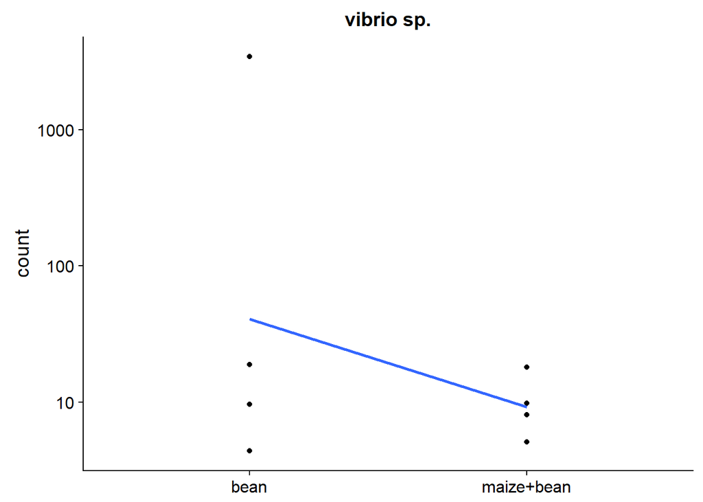

```r
plots.list <- lapply(row.names(head(sps_bean_sigtab_down[order(sps_bean_sigtab_down$padj),])),
                     function(x) {
                       d <- plotCounts(bmvsbc_sps, x, intgroup=c("culture"), returnData=TRUE)
                       ggplot(d, aes(x=culture, y=count, group=1)) +
                         geom_point() + stat_smooth(se=FALSE,method="loess") + scale_y_log10() +
                         ggtitle(tax[x,"Species"]) +
                         theme(axis.title.x = element_blank(), legend.title=element_blank(), legend.position="top", legend.box="horizontal", legend.key.height = unit(.5, "cm"),legend.text=element_text(size=6))
                     }
)
do.call(grid.arrange,plots.list)
```

So here the Species from the Acinetobacter genus didn’t display adjusted p-values above the 5 percent threshold. Maybe the difference between those specie abundances is not big enough to be detected when taken separately, or not big enough to be detected because of a more stringent p-value correction due to a higher number of species than genus. Besides that, the result for *Vibrio sp.* is the same than for *Vibrio* genus.

##### High variance

```r
bemobeco_sps_highVar0.5 =
  filter_taxa(bemobeco_sps,
              function(x) var(x) > 0.5, TRUE)

bean_sps_highVar0.5 <- as.data.frame (bemobeco_sps_highVar0.5@otu_table)

bean_sps_highVar0.5_sup12 <- bean_sps_highVar0.5[rowSums(bean_sps_highVar0.5) > 12,]

bean_sps_highVar0.5_sup12_max5 <- bean_sps_highVar0.5_sup12[rowSums(bean_sps_highVar0.5_sup12 ==0) <= 5,]

bmvsbc_hv_sps_s12m5 <- DESeqDataSetFromMatrix(bean_sps_highVar0.5_sup12_max5,
                                 meta_data_bemobeco,
                                 design = ~ culture)
bmvsbc_hv_sps_s12m5 <- DESeq(bmvsbc_hv_sps_s12m5)

bmvsbc_hv_sps_s12m5_res <- results(bmvsbc_hv_sps_s12m5, cooksCutoff = FALSE)

alpha = 0.05

sps_bean_hv_s12m5_sigtab = bmvsbc_hv_sps_s12m5_res[which(bmvsbc_hv_sps_s12m5_res$padj <= alpha), ]

sps_bean_hv_s12m5_sigtab
```

```
## log2 fold change (MLE): culture maize.bean vs bean
## Wald test p-value: culture maize.bean vs bean
## DataFrame with 1 row and 6 columns
##        baseMean log2FoldChange     lfcSE      stat       pvalue       padj
##       <numeric>      <numeric> <numeric> <numeric>    <numeric>  <numeric>
## OTU33  436.8806      -6.490668  1.551018 -4.184779 2.854443e-05 0.02497638
```

```r
sps_bean_hv_s12m5_sigtab_down <- sps_bean_hv_s12m5_sigtab[which(sps_bean_hv_s12m5_sigtab@listData$log2FoldChange < 0),]

cbind(head(sps_bean_hv_s12m5_sigtab_down[order(sps_bean_hv_s12m5_sigtab_down$padj),]), tax[row.names(head(sps_bean_hv_s12m5_sigtab_down[order(sps_bean_hv_s12m5_sigtab_down$padj),])),2:7])
```

```
## DataFrame with 1 row and 12 columns
##        baseMean log2FoldChange     lfcSE      stat       pvalue       padj
##       <numeric>      <numeric> <numeric> <numeric>    <numeric>  <numeric>
## OTU33  436.8806      -6.490668  1.551018 -4.184779 2.854443e-05 0.02497638
##               Phylum               Class       Order       Family    Genus
##             <factor>            <factor>    <factor>     <factor> <factor>
## OTU33 proteobacteria gammaproteobacteria vibrionales vibrionaceae   vibrio
##          Species
##         <factor>
## OTU33 vibrio sp.
```

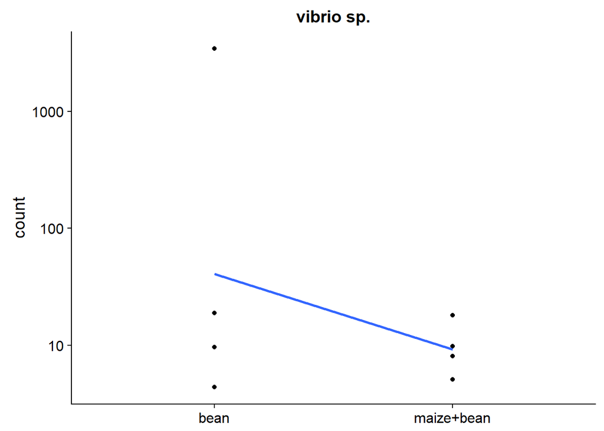

```r
plots.list <- lapply(row.names(head(sps_bean_hv_s12m5_sigtab_down[order(sps_bean_hv_s12m5_sigtab_down$padj),])),
                     function(x) {
                       d <- plotCounts(bmvsbc_hv_sps_s12m5, x, intgroup=c("culture"), returnData=TRUE)
                       ggplot(d, aes(x=culture, y=count, group=1)) +
                         geom_point() + stat_smooth(se=FALSE,method="loess") + scale_y_log10() +
                         ggtitle(tax[x,"Species"]) +
                         theme(axis.title.x = element_blank(), legend.title=element_blank(), legend.position="top", legend.box="horizontal", legend.key.height = unit(.5, "cm"),legend.text=element_text(size=6))
                     }
)
do.call(grid.arrange,plots.list)
```

Same result that without variance filtering.